# Driving The Donut

by Evan Curtis Johnson

26 May, 2017

## Table of Contents

#### 0. Foreword

0.1 who is this tutorial for?  
0.2 A high level model description  
0.3 Pros and cons of using this model  
0.4 A slightly lower level description  
0.4.1 Overview of program structure  
0.4.2 Overview of single time step

#### 1. Getting Started: Necessary background information

1.1 Java Setup  
1.2 Notes on rJava  
1.2.1 Types  
1.2.2 Constructors, methods, and static methods  
1.2.3 Converting between java arrays and R arrays  
1.2.4 Indexing in R vs indexing in Java  
1.2.5 Copying R objects vs copying Java objects  
1.2.6 Other useful rJava functions  
1.3 A basic community  
1.4 Getting data: some general-use functions

#### 2 Adding and removing individuals/species

2.1 Inoculating/adding individuals  
2.1.1 Using the species constructor  
2.1.2 Using the addCritters class  
2.1.2.1 Using the addCritters Class to randomly add individuals  
2.1.2.2 Using the addCritters Class to add individuals uniformly  
2.1.2.3 Using the addCritters Class to add individuals in a tight cluster  
2.1.2.4 Using the addCritters Class to add a single individual  
2.1.2.5 Using the addCritters Class to add individuals around other individuals  
2.1.2.6 Using the addCritters Class and avoiding overwriting a subset of heterospecifics  
2.1.2.7 Using the addCritters Class to add multiple species at once  
2.2 Removing individuals using the removeCritters class

#### 3. Traversing time: step and scramble methods

3.1 A few notes on dt  
3.2 Stepping  
3.3 Scrambling  
3.4 Stepping until something happens, the ITerminateCondition interface

#### 4. Time series stuff

4.1 Construcing the object  
4.2 Cbundance time series  
4.3 Grid time series  
4.4 Flexible time series: abundance, pair correlations, lambda tilda, and beyond  
4.5 Time series until something happens: the return of ITerminateCondition

#### 5. Measuring invasion fitness

5.1 Binary persistence  
5.2 Empirical lambda  
5.3 Expected lambda

#### 6. Visualizing the simulations

6.1 R plots and Sys.sleep  
6.2 Animation

#### 7. Modifying baseline species and diffusing “general effects”

7.1 What exactly is a baseline species?  
7.2 A motivating example: a lotka-Volterra predator-prey community  
7.3 General effects  
7.3.1 Diffusing general effects  
7.3.2 Making general effects visible to other species  
7.4 Setting up the birth and death processes

#### 8. A quantitative cheater community

8.1 A two species community  
8.2 A three species community - introducin the double-producer

#### 9. Paired lattices: decoupling competition for space

9.1 What are paired lattices and why would we want to make them?  
9.2 Setting up the paired lattice  
9.2.1 Telling species where they live  
9.2.2 Telling species where they can or can’t recruit

#### 10. Setting the seed

#### 11 Individual based evolution

11.1 The setup, from a software engineering perspective  
11.2 The key ingredient: a mutation function  
11.3 How to start evolution: an example with dispersal distance  
11.4 Stopping evolution  
11.5 Getting individual-based trait data  
11.5.1 getting trait data for any type of trait  
11.5.2 getting trait data for discrete traits  
11.6 Evolving general effect magnitude: an example with a predator-prey community  
11.7 Evolving general effect diffusiveness: an example with a predator-prey community  
11.8 Evolving mutation proabilities  
11.9 Evolving mutation magnitudes  
11.10 Evolving q: an example with quantitative cheaters

# 0. Foreword

Welcome to the tutorial on how to use my stochastic spatial model. If you want to explore spatial ecological phenomena, you’ve come to the right place! Well, maybe. While a good deal of effort has been put into making my model flexible, it is not capable of modeling every system. Before diving in, please read the model description (0.2) to see if your phenomenon/community of interest is compatible with my model. If not, I recommend using netLogo for it’s versatility and ease of use. If you find that your model requires more speed or more fine-grained control of the dynamics, I recommend Java. It’s relatively fast and relatively easy to program in (and hopefully you can utilize some of my code). Additionally, Java can easily communicate with R or Mathematica (through the rJava and JLink packages, respectively) for running simulations in an interpreted environment. For our purposes, this means we can mess around with the model in a dynamic way. If speed is *really* your biggest issue, use c++ and cuda.

This tutorial was designed to be as comprehensive as possible without forcing you to dredge through the minutia of the model. However, I will delve into program structure at some points. If the Computer Science jargon is intimidating, don’t worry! For the most part, it’s unnecessary that you fully understand these sections. In other sections, I may not provide enough detail. This is more of a problem, and the only solution is to go through the Java Docs (which are largely incomplete as of 5/9/17) or the code itself. The model was written in Java, so it would be helpful to have a semester of object-oriented programming under your belt.

A few notes on jargon: Stochastic spatial models have many aliases: agent-based models (typically in social sciences), interacting particle systems (typically in physics), stochastic cellular automata (typically in computer science and complex systems), and individual-based models/IBMs (typically in ecology). This terminology is important to know if you want to search the literature. For the sake of brevity, I will usually refer to my model as simply, “the model”, or “the IBM”.

#### 0.1 Who is this tutorial for?

This model is for the ecological researcher who is interested in general spatial phenomena. As Levin and Durrett point out in their fantastic paper *the importance of being discrete (and spatial)* (1994), there are two important properties of stochastic spatial models: discreteness of individuals and spatially explicit dynamics. Compared to their non-discrete counterpart - reaction-diffusion models - stochastic spatial models tend to help individuals get away from individuals that affect them negatively. If interaction neighborhoods are small, a rare species is likely to persist in pockets where its antagonist is absent. Additionally, unlike their spatially implicit counterparts - haystack models - stochastic spatial models tend to allow for beneficial spatial aggregation. The clearest example of this is the two species competitive Lotka Volterra model with an unstable equilibrium. In the mean-field case, the winner is determined by initial conditions. In the spatially explicit case, the winner is determined by competition coefficients.

You should only use this model if you are interested in the effects of discreteness and spatial explicitness. While a mean field formulation can be recovered by making dispersal neighborhood and diffusion neighborhoods (of general effects) large, I do not recommend you that you use the IBM exclusively for this purpose (unless you’re using the visualization to sharpen your intuition!). IBMS are stochastic in nature and have a large number of degrees of freedom. Thse properties do not make IBMs very amenable to important aspects of analysis such as finding unstable equilibria and local stability analysis, although equation-free methods are poised to solve this problem.

You should not use the IBM to make quantitative predictions about any given system. IBMs for actual management usually require the incorporation of complex life-histories and more realistic neighborhoods (the square Moore neighborhood here was chosen for computational convenience). Additionally, it has been shown (can’t find cit) that quantitative outcomes are dependent on the order of births, deaths, and recruitment. Here, these events are hard-coded to occur simultaneously. Netlogo is the idea language for rapidly prototyping complex management IBMs.

#### 0.2 A high-level model description.

The IBM depicts the movement of individuals on a two-dimensional landscape. I will usually refer to the lanscape as the lattice or the environmental grid. The lattice has periodic boundary conditions, which essentially wrap the landscape into a torus (a.k.a a donut). This tutorial aims to teach you how to control this donut, hence the somewhat confusing name of this document.

Adults are sessile and cannot be displaced, while propagules are passively dispersed and can only become established if they happen across an empty location and beat out other propagules in the recruitment lottery. Adults can disseminate/diffuse-out *“general effects”* around them which may effect the fecundity, survival, or recruitment of other individuals (see 7.). These *“general effects”* can be thought of as local competition coefficients, although they are far more flexible than that.

A few prominent features - age structure and the patch preemption - suggest that the model most closely approximates communities of plants or sessile marine animals. However, the model can be used to study general spatial phenomena which can extend to many communities with the help of assumptions. For example, active dispersal can be modelled if individuals disperse to resources which are randomly distributed in space. Additionally, the spatial extent of the “general effects” need not be a region of nutrient uptake. It could just easily be the foraging range of a top predator, as long as the predator sufficiently explores and it’s range during a single a time step.

#### 0.3 Pros and cons of using this model

The IBM is designed to be as fast as possible (within the bounds of flexibility and maintainability). On this note, the IBM utilizes a two dimensional moving window algorithm to distribute “general effects” and propagules. For large neighborhoods, this offers immense speed ups. Additionally, intraspecific variation can be incorporated without creating an immutable object for each individual (for more information, see 11.1). This offers a performance boost for communities with larger lattices. Most importantly, the synchronous updating of birth and deaths for all individuals allows us to measure individual fitness potential (stochasticity ignored) with fitness generating functions. This, in turn, allows us directly measure how individual fitness (or components of fitness) varies through space or is related to the composition of a neighborhood.

#### 0.4 A slightly lower level description.

#### 0.4.1 Overview of program structure

A Community object has an Environment object and a list of Species objects. The Environment contains the lattice, which is a two dimensional array of integers where different species are represented as different integers. Intraspecific variation can be incorporated into the model (see 11.), but this variation is not visible on the environment’s lattice. The Species object is a sort of “god object” which tells individuals how to behave. It contains essential generic interface types such as IBirthProcess, IDeathProcess, and IDispersalTrait. In part, the IBM’s flexibility lies in the ability to mix and match specific implementations of these interface types. The scaffold for any species is what I call a “basic species”. A “basic species” experiences no interspecific or intraspecific interactions; and fecundity and death are spatially invariant. An ensemble of “basic species” leads to a “basic community” (1.3). Every model we build will start with one or more “basic species”, and we will build up from there.

#### 0.4.2 Overview of single time step

The community dynamics move through time in discrete time steps, although a continuous time system can be well approximated if the length of the discrete step (in time units) is small enough; see 3.1. During a single time step, the adults may or may not diffuse “general effects” around them in a Moore (square) neighborhood (see class LocalLVAllSpecies). Species can use these “general effects” to inform their fecundity, death probability, or recruitment probability. Next, all individuals try to produce propagules (class Species has an IBirthProccss; also see class CommunityUtilsFecundity). The total density of propagules that an adult produces is distributed uniformly in a Moore (square) neighborhood around the adult (see class PRG). Propagules at empty sites enter a lottery to determine who will recruit (see class CommuntyUtilsStep). All adults then may die with some probability (class Species has an IDeathProcess). Thus, an adult may die and produce offspring in a single time step. Effort must be taken to define birth rates and general effects so that the sum of probabilities of recruitment at a single empty site will never be greater than 1 (see 1.3).

# 1. Getting Started: Necessary background information

#### 1.1 Java Setup

The IBM is written in Java, but we can access it in R with the rJava package. Why not just work in java? With rJava, we can access the speed of Java while dynamically altering simulations, grabbing data, and accessing R functions. Basically, we can work on the fly *and* utilize all the funcionality that R has to offer.

Install the R - Java interface.

```r
install.packages("rJava", repos="http://cran.rstudio.com/")
```

Load the R - Java interface

```r
library(rJava)
```

This next snippet will start the java virtual machine and tell R where the java classes are.

```r
.jinit()
```

```
## [1] 0
```

```r
# this is my class path, replace it with your own
javaClassPath <- "/C:/Users/Evan/workspace/IBMGeneralEvolvable/"
.jaddClassPath(javaClassPath)
```

If you ever get a heap overflow error, you’ll need to allocate more memory to java. Here, I allocate 2 gigabytes.

```r
.jinit(parameters = getOption("-Xmx2048m"))
```

#### 1.2 Notes on rJava

#### 1.2.1 Types

R interprets the type of object you want, whereas java demands that you specify the type. Most of Java’s types have a one-to-one corollary in R, which makes it easy for rJava to interpret what type of object you want to send to java. For example, rJava knows that TRUE in R is a boolean in Java. However, all of R’s numeric values are automatically doubles (double-precision numbers), so if java needs an integer, you have to convert to R’s integer type with `as.integer(my_value)`. Here’s an example…

```r
aNum <- 7
is.integer(aNum)
```

```
## [1] FALSE
```

```r
is.integer(aNum)
```

```
## [1] FALSE
```

```r
aNum <- as.integer(aNum)
is.integer(aNum)
```

```
## [1] TRUE
```

#### 1.2.2 Constructors, methods, and static methods

In RJava, you construct an object using `.jnew("obj_name", params...)`. You can use methods with `.jcall(java_obj, "return_signature_in_JNI", "method_name", params...)`. However, there is a simpler way that mirrors java’s syntax: use the `$` opeerator like you would use a period in Java. For example, if your object (implicit parameter) is a car, your method is drive, and your explicit parameter is integer miles…

In Java: `car.drive(10)`  
In R: `car$drive(as.integer(10))`

The dollar sign operator’s ease-of-use trades off with speed. For our purposes, it won’t make much of a difference since the performance bottleneck will almost always be in Java.

Many class have multiple constructors. To see these, use…

```r
.jconstructors("Species")
```

```
## [1] "public Species(java.lang.String,double,double,int,int,int,boolean)"
## [2] "public Species(double,double,int,int,int,boolean)"
## [3] "public Species(java.lang.String,double,double,int)"
## [4] "public Species(double,double,int)"
```

Unfortunatly, this function doesn’t show the names of the parameters. Consult the Java Docs for that.

You can also look at the methods. Again, the Java Docs should be more informative.

```r
# I use head becuase there are a lot of methods
head(.jmethods("Species"))
```

```
## [1] "public void Species.test()"
## [2] "public void Species.setEnvGridIndexesThatAffectRecruitment(int[])"
## [3] "public void Species.setEnvGridValuesThatAffectRecruitment(int[])"
## [4] "public void Species.setupSpeciesAfterCommunityIsCreated(Community)"
## [5] "public void Species.resetAffectingLVEffectsByIndicator()"
## [6] "public boolean Species.canRecruitIfCritterCanOverwriteHeterospecifics(Community,Location)"
```

To call a Static method (method that requires no instance) use the `J` function.

```r
J("CorrectLambdaWithDt")$correct(lambda = 1.5, dt = 0.1)
```

```
## [1] 57.66504
```

#### 1.2.3 Converting between java arrays and R arrays

R doesn’t know how to represent java arrays without post processing. Make a java array…

```r
jArr <- .jarray(c(1,2,3))
```

To convert back to an R vector…

```r
.jevalArray(jArr)
```

```
## [1] 1 2 3
```

Say that you want to make a two dimensional java array. Use the `dispatch = TRUE` argument.

```r
jArr2 <- .jarray(matrix(1:9, nrow = 3), dispatch = TRUE)
```

Using `.jevalArray` plainly will give a you a list of java arrays. To get your original matrix back, use the `simplify = TRUE` argument. This also works for higher dimensional arrays.

```r
.jevalArray(jArr2, simplify = TRUE)
```

```
##      [,1] [,2] [,3]
## [1,]    1    4    7
## [2,]    2    5    8
## [3,]    3    6    9
```

#### 1.2.4 Indexing in R vs indexing in Java

A natural way to index items in a list or array is to start at one and count up. This is how R counts.

```r
aVector <- c(32, 33, 34)
aVector[1]
```

```
## [1] 32
```

Java starts at zero and counts up. You won’t have to accommodate this quirk when you deal with arrays, since you should have converted the java array to an R array.

```r
# make a java array
aJArray <- .jarray(c(32,33,34))
# convert to R array
rArray <- .jevalArray(aJArray)
rArray[1]
```

```
## [1] 32
```

You *will* have to accommodate Java’s zero-based indexing when you try to get items from an arraylist. Commonly, you will have to get species from an arraylist of species (which is part of a community). If you want the first species in the list, you will have to use…

```r
com$getSpeciesList()$get(as.integer(0))
```

Weird, right? Oftentimes, methods have an argument that is a speciesValue or an array of speciesValue. This argument is asking for the natural index of the species in the community’s list of species. So, if you want to measure Lambda Tilda (see 5.) of the first species in the species list, use…

```r
#cmake object that measure lambda tilda
# the last argument is the speciesValue
.jnew("LambdaTilda", com, as.integer(1))
```

In section 7, you’ll learn how to distribute “general effects” to different species. If you want to tell the first species to give its general effects to itself, you’ll have to use both ways of indexing in the same expression.

```r
# what this line is saying: get species 1; tell the species to give a general effect (eff1) to speciesValue 1 (itself)
list$get(as.integer(0))$setLocalEffect(as.integer(1), eff1)
```

If you rummage through the Java code, you may find methods that ask for a speciesIndex instead of speciesValue. This is where you would supply an argument that assumes Java’s zero-based indexing system.

#### 1.2.5 Copying R objects vs copying Java objects

This section is extremely important. There is a fundamental difference between the ways in which objects are copied in R and Java, and not taking the time to understand the difference can result in some serious head-scrathcing down the road.

When you tell R to copy with the assignment `<-` operator, R actually allocates new memory and recreates an object at that memory address. While the two objects may be identical in composition, they are not the the same thing. To see this…

```r
vec1 <- c(1,2,3)
# copy a version of vec1 called vec2
vec2 <- vec1
# modify the copy
vec2[1] <- 68
vec1
```

```
## [1] 1 2 3
```

Vec1 is unaltered by the modification of vec2. This is what is called a Deep Copy.

Java does not make deep copies automatically…

```r
sp1 <- .jnew("Species", 0.5, 0.3, as.integer(2))
sp1$setGridProxy(as.integer(1))
sp2 <- sp1
sp2$setGridProxy(as.integer(68))
sp1$getGridProxy()
```

```
## [1] 68
```

Sp1 is affected by a modification of sp2 because sp1 is the same thing as sp2. When you use the assignment operator in Java, you don’t allocate new memory, you simply add a pointer to associate the new variable name with the same old memory address. It should be noted that primitve objects (e.g. integers, booleans, doubles, floats) are exceptions to this rule. If you want a truly deep copy of a Java object, use the static method `deepCopy`

```r
sp1 <- .jnew("Species", 0.5, 0.3, as.integer(2))
sp1$setGridProxy(as.integer(1))
sp2 <- J("DeepCopy")$deepCopy(sp1)
sp2$setGridProxy(as.integer(68))
sp1$getGridProxy()
```

```
## [1] 1
```

My deep copy method utilizes serialization, which can be rather slow. For reference, it takes approximately as long as a 50-100 steps on a 200x200 lattice with a basic community (what this means will become clearer as you run more simulations on your own).

If you are using `deepCopy` to run replicates of a community from the same initial condition, there are a few things to keep in mind. The first is that random number generators are also copied, so there will be no variation across replicates unless you randomly set the seed of the random number generators. Details are given in 10, but for most cases, the following snippet should suffice.

```r
com$getEnvironment()$setSeedAtOneLevel(as.integer(1), as.integer(sample(1:10000, 1)))
```

The second thing to keep in mind is that there’s a faster way to make community replicates. Use…

```r
#prior to replicates
comGrid <- com$getEnvironment()$getGrid()
for(i in 1:numReps)
{
  com$getEnvironment()$setGrid(comGrid)
  #do stuff
}
```

This approach doesn’t require you to re-randomize the seed, but **it only works when there is no intraspecific variation** (see 11).

Thirdly, if you decide to extend the Java code, keep in mind that anything you want to deep copy has to implement the Serializable interface.

#### 1.2.6 Other useful rJava functions

`.jcast(obj, "castToThisType")` will be used in 11. to convert specific objects to their generic interface type. An interface is a sort of contract that forces an object to have certain methods.

`.jinstanceOf(obj, "targetClass")` will tell you if your object is of a certain type.

`.jnull("class")` will give a null object of the specified class type

#### 1.3 A basic community

In other sections, I will skip this initialization process with the hidden user-generated R functions: `com <- create2SpeciesCommunity()` and `com <- create2SpeciesCommunityAndInoculate()`

In a basic community, individuals don’t diffuse out general effects. They just send out their propagules over some dispersal neighborhood. The dispersalAbility parameter in the Species constructor is sort of like the “radius” of the square neighborhood. Technically, the length of a side of the square dispersal neighborhood is (2 * dipsersalAbility) + 1. So dispersalAbility = 1 is the 8 nearest-neighbor neighborhood, and dispersalAbility = 2 is the 24 neighbor neighborhood. The total density of propagules that a species produces (defined by the IBirthProcess object in the Species object) is divided by the number sites in the square dispersal neighborhood. That number is then distributed (in class CommunityUtilsFecundity) to each site in the dispersal neighborhood. No propagules are distributed to the center site, where the propagule-generating individual is.

For example, if an individual has a dispersalAbility of 1 and happens to produce a density of 1 propagule, then each of that individual’s 8 nearest neighbors will receive a propagule density of 1/8. If that site is already occupied, all the propagules immediately die. However, if the site is empty, then the probability of the adult individual producing an offspring in that site is 1/8. You can see how it’s important for fecundities to always be less than one - it ensures that the sum of probabilities of individuals producing offspring in an empty site is less than 1. In turn, an axiom of probability theory is satisfied.

```r
# parameters for creating species and the community.
gridLength = 100
dt = 1
n1InitAbund = 2000
n2InitAbund = 2000
r1 = 0.46
r2 = 0.46
d1 = 0.2
d2 = 0.2
disp1 <- 1
disp2 <- 2
```

The community constructor requires an arraylist of species. First, make an empty list.

```r
# put species objects in a list
list <- .jnew("java.util.ArrayList")
```

Then put any number of species in the list. Here, I put in two species.

```r
# add the first species
list$add(
  .jnew(
    "Species",
    r1,
    d1,
    as.integer(disp1)
  )
)
```

```
## [1] TRUE
```

```r
# add the second species
list$add(
  .jnew(
    "Species",
    r2,
    d2,
    as.integer(disp2)
  )
)
```

```
## [1] TRUE
```

Finally, instantiate the community.

```r
# creates a community
com <-
  .jnew(
    "Community",
    as.integer(gridLength),
    dt,
    list
  )
```

#### 1.4 Getting data: some general-use functions

To get the lattice, use…

```r
grid <- .jevalArray(com$getEnvironment()$getGrid(), simplify = TRUE)
str(grid)
```

```
##  int [1, 1:100, 1:100] 0 0 0 0 0 0 0 0 0 0 ...
```

Notice that the lattice has three dimensions. The first dimension is the index of the lattice on the stack of lattices (see 9.). The basic community only has one lattice.

To get abundances, use…

```r
# returns a vector of abundaces
com$getAbundances()
# returns a vector of densities
com$getAbundances(TRUE)
# get the abundane of a single species
com$getSpeciesList()$get(as.integer(0))$getAbundance()
```

How long as the simulation been running? (more in 3.1)

```r
com <- create2SpeciesCommunityAndInoculate()
com$setDt(0.1)
com$stepThroughTime(as.integer(100))
com$getTime()
com$getStepCallCounter()
```

How about the expected fitness, expected births, and death probability of an individual? Use the following functions. Population-level fitness is discussed more in 5.. There are a few more cool Species methods that give you quantities pertaining to individuals. Consult the Java Docs.

```r
com <- create2SpeciesCommunityAndInoculate()
grid <- .jevalArray(com$getEnvironment()$getGrid(), simplify = TRUE)
firstLoc <- which(grid[1,,] == 1, arr.ind = TRUE)[1,]
com$getSpeciesList()$get(as.integer(0))$getFitness(.jnew("Location", as.integer(firstLoc[1]),as.integer(firstLoc[2])))
```

```
## [1] 1.325
```

```r
com$getSpeciesList()$get(as.integer(0))$getBirthRate(.jnew("Location", as.integer(10), as.integer(10)))
```

```
## [1] 0.6
```

```r
com$getSpeciesList()$get(as.integer(0))$getDeathRate(.jnew("Location", as.integer(10), as.integer(10)))
```

```
## [1] 0.2
```

# 2. Adding and removing individuals

#### 2.1 Inoculating species / adding individuals

In section 11., we will play around with evolution and generate intraspecific variation. Here, we need to address the issue of adding new individuals when the individuals could plausibly take on different many trait values. What trait values do we give to these new individuals? When randomly adding individuals to the lattice, it would be reasonable to randomly draw from the existing distribution of trait values. The model is not currently capable of this, so individuals that are added randomly or uniformly (as in 2.1.1, 2.1.2.1, 2.1.2.2, 2.1.2.3, 2.1.2.4, 2.1.2.6, 2.1.2.7) will receive the average trait value of it’s species. If there are no individuals such that an average cannot be taken, the individuals will be given a baseline trait that is given by the non-evolvable trait that the evolvable trait overwrites (see 11.1).Individuals that are added close to their existent conspecifics (as in 2.1.2.5) will inherit the traits of those nearby conspecifics.

Most users won’t have to worry about all of the above details, since most users will only add individuals in order to inoculate a species.

#### 2.1.1 Using the species constructor

There are a few ways to inoculate species. If you want individuals to be randomly placed on the grid at a pre-determined time, you can take care of inoculation in the construction of the species. Check out this example below.

```r
# regular params
gridLength = 100
dt = 1
n1InitAbund = 2000
n2InitAbund = 2000
r1 = 0.46
r2 = 0.46
d1 = 0.2
d2 = 0.2
disp1 <- 1
disp2 <- 2

#inoculation params
n1InitAbund <- 1000 # number of individuals to be inoculate
n1InoculationTime <- 0 # what time does inoculation happen? automatically scaled my
n1Overwrite <- TRUE # can you overwrite heterospecifics during inoculation. Meaningless if this is the first species to be inoculated
n2InitAbund <- 1000
n2InoculationTime <- 10
n2Overwrite <- TRUE

# put species objects in a list
list <- .jnew("java.util.ArrayList")

# add the first species
list$add(
  .jnew(
    "Species",
    r1,
    d1,
    as.integer(disp1),
    as.integer(n1InitAbund),
    as.integer(n1InoculationTime),
    n1Overwrite
  )
)
```

```
## [1] TRUE
```

```r
# add the second species
list$add(
  .jnew(
    "Species",
    r2,
    d2,
    as.integer(disp2),
    as.integer(n2InitAbund),
    as.integer(n2InoculationTime),
    n2Overwrite
  )
)
```

```
## [1] TRUE
```

```r
# creates a community
com <-
  .jnew(
    "Community",
    as.integer(gridLength),
    dt,
    list
  )

# at time zero, no one is around
com$getAbundances()
```

```
## [1] 0 0
```

```r
# do one step, n1 should have been inoculated
com$step()
com$getAbundances()
```

```
## [1] 1185    0
```

```r
# what about n2...
com$step(as.integer(10))
com$getAbundances()
```

```
## [1] 2766 1072
```

Notice that n2’s abundance isn’t exactly 1000. This is because n2 was inoculated and then a time step was executed. This is one of the reasons to prefer the AddCritters class.

#### 2.1.2 Using the addCritters Class

I prefer using AddCritters; it gives you more control.

#### 2.1.2.1 Using the addCritters Class to randomly add individuals

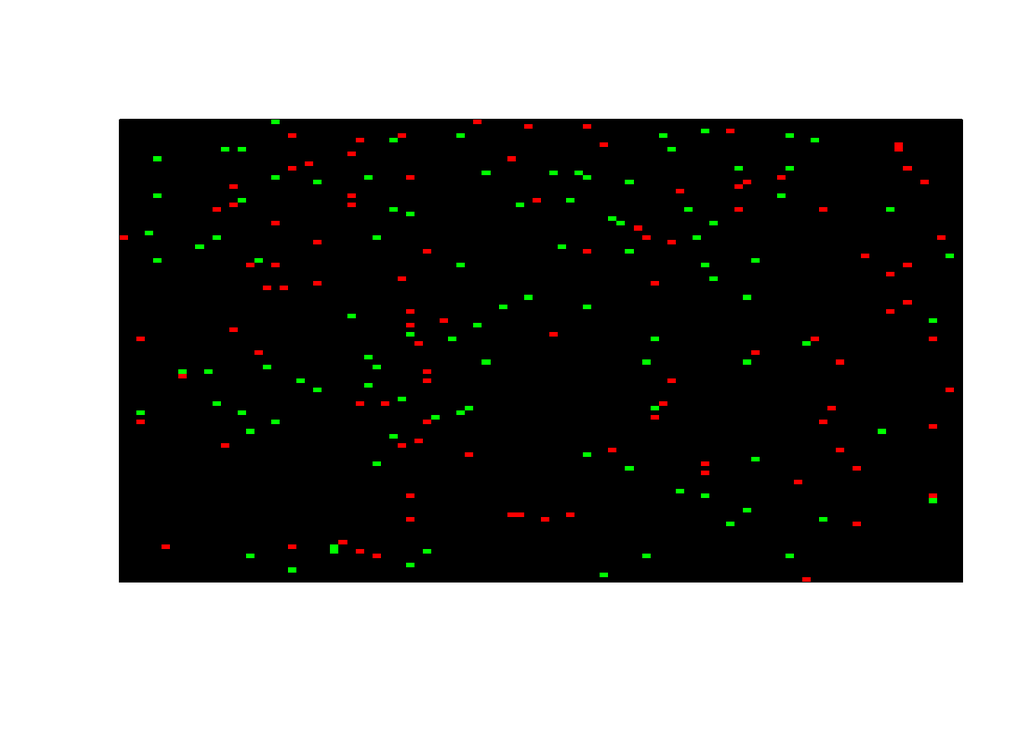

```r
com <- create2SpeciesCommunity()
# the params here are community object, species number, and should overwrite heterospecifics
ac <- .jnew("AddCritters", com, as.integer(1), n1Overwrite)
# to add critters randomly
ac$addCrittersRandomly(as.integer(100))

ac <- .jnew("AddCritters", com, as.integer(2), n1Overwrite)
# to add critters randomly
ac$addCrittersRandomly(as.integer(100))
# see?
# install.packages("Matrix")
library(Matrix)

grid <- .jevalArray(com$getEnvironment()$getGrid(), simplify = TRUE)[1,,]
myColors <- c("Black", "Red", "Green" )
image(grid, xaxt = "n", yaxt = "n", col = myColors)
```

#### 2.1.2.2 using the addCritters Class to add individuals uniformly

You can also add critters uniformly (to maximize the distance between individuals)

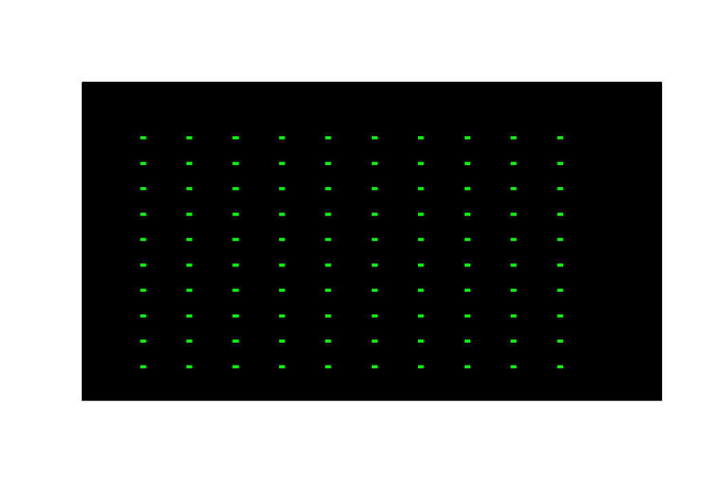

```r
com <- create2SpeciesCommunity()
ac <- .jnew("AddCritters", com, as.integer(1), n1Overwrite)

ac$addCrittersUniformly(as.integer(100))
# see?
# install.packages("Matrix")
library(Matrix)
grid <- .jevalArray(com$getEnvironment()$getGrid(), simplify = TRUE)[1,,]
myColors <- c("Black", "Green" )
image(grid, xaxt = "n", yaxt = "n", col = myColors)
```

#### 2.1.2.3 using the addCritters Class to add individuals in a tight cluster

Say you want to inoculate a species in a tight cluster. The following code will put species 1 in a 10x10 box, the bottom-left corner of which is centered at 50,50

```r
com <- create2SpeciesCommunity()
ac <- .jnew("AddCritters", com, as.integer(1), FALSE)
ac$setReferenceLocation(as.integer(50), as.integer(50))
ac$setDispersalLength(as.integer(10))
ac$addCrittersRandomly(as.integer(100))
com$getAbundances()# see?
```

```
## [1] 100   0
```

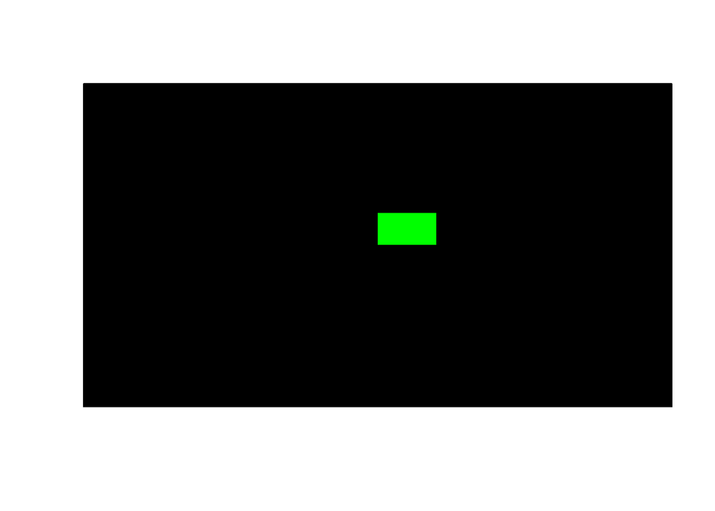

```r
# install.packages("Matrix")
library(Matrix)
grid <- .jevalArray(com$getEnvironment()$getGrid(), simplify = TRUE)[1,,]
myColors <- c("Black",  "Green" )
image(grid, xaxt = "n", yaxt = "n", col = myColors)
```

#### 2.1.2.4 Using the addCritters Class to add a single individual

If you want to add one Critter at one location…

```r
com <- create2SpeciesCommunity()
ac <- .jnew("AddCritters", com, as.integer(1), FALSE)
ac$setReferenceLocation(as.integer(50), as.integer(50))
ac$setDispersalLength(as.integer(1))
ac$addCrittersRandomly(as.integer(1))
com$getAbundances()# see?
```

```
## [1] 1 0
```

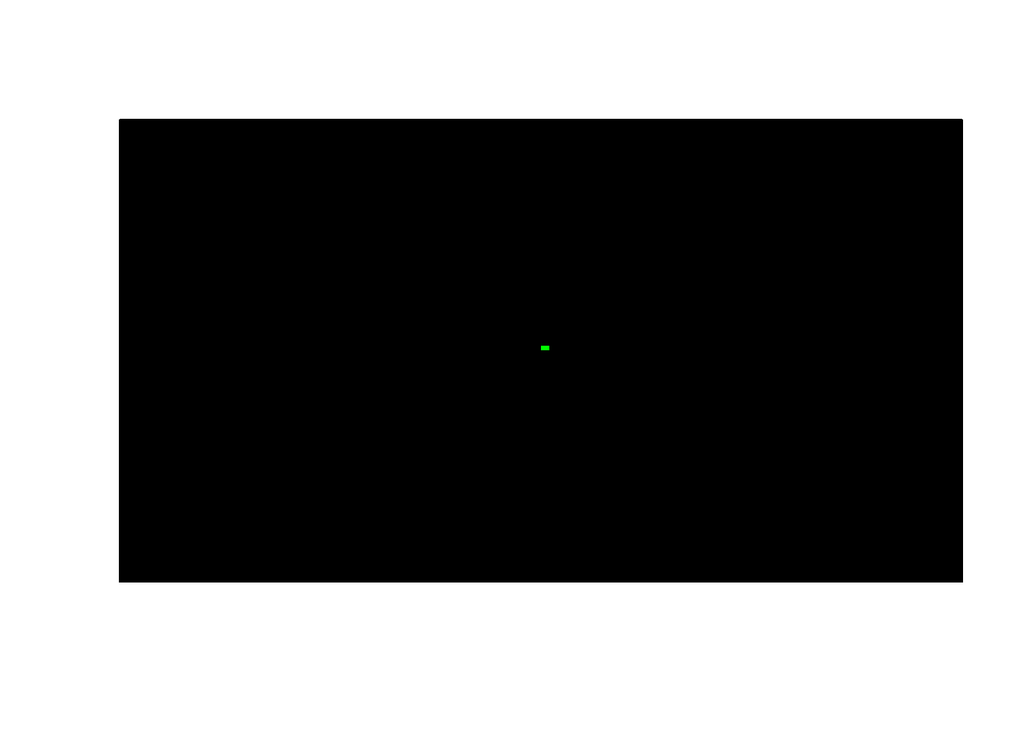

```r
# install.packages("Matrix")
library(Matrix)
grid <- .jevalArray(com$getEnvironment()$getGrid(), simplify = TRUE)[1,,]
myColors <- c("Black", "Green" )
image(grid, xaxt = "n", yaxt = "n", col = myColors)
```

#### 2.1.2.5 Using the addCritters Class to add individuals around other individuals

You can also use `addCrittersNearby` to add critters in the vicinity of other conspecifics. This is one way of adding critters and somewhat preserving spatial structure.

```r
com <- create2SpeciesCommunity()
ac <- .jnew("AddCritters", com, as.integer(1), FALSE)
ac$setReferenceLocation(as.integer(50), as.integer(50))
ac$setDispersalLength(as.integer(10))
ac$addCrittersRandomly(as.integer(100))
ac$addCrittersNearby(as.integer(100))
com$getAbundances()# see?
```

```
## [1] 200   0
```

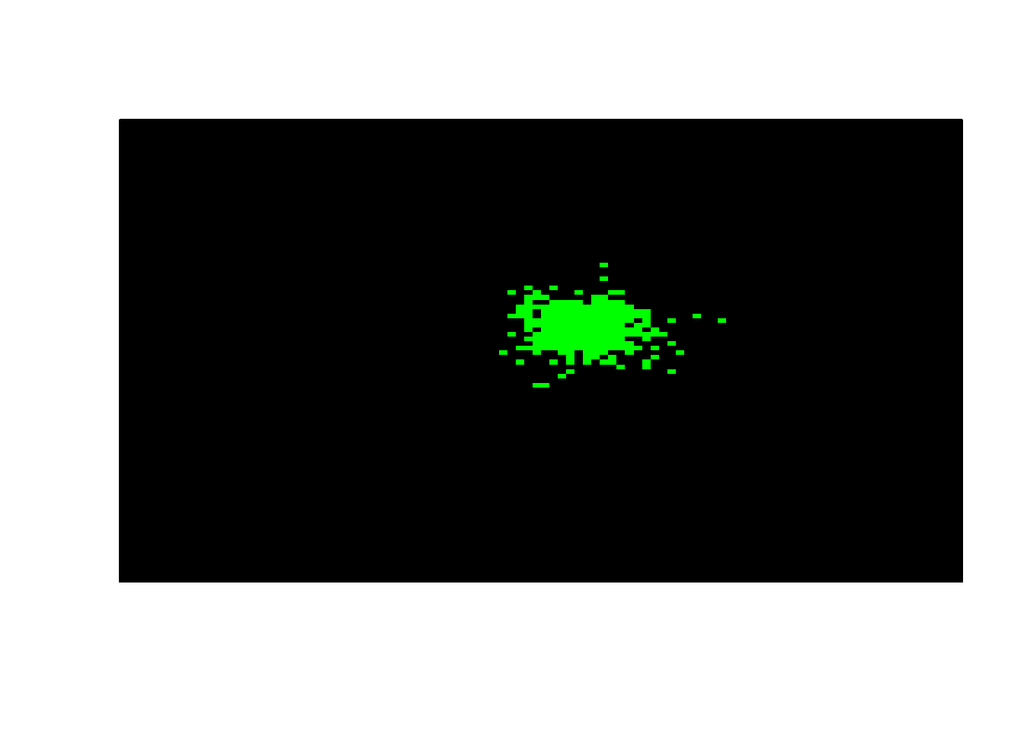

```r
# install.packages("Matrix")
library(Matrix)
grid <- .jevalArray(com$getEnvironment()$getGrid(), simplify = TRUE)[1,,]
myColors <- c("Black", "Green" )
image(grid, xaxt = "n", yaxt = "n", col = myColors)
```

#### 2.1.2.6 Using the addCritters Class and avoiding overwriting a subset of heterospecifics

Say that you want to be able to overwrite all but one type of heterospecific, use…

`ac$addCrittersRandomlyWithLimitations(as.integer(100), .jarray(c(as.integer(offLimitSpeciesValues))))`  
`ac$addCrittersNearbyWithLimitations(as.integer(100), .jarray(c(as.integer(offLimitSpeciesValues))))`

#### 2.1.2.7 Using the addCrittersMultipleSpecies Class to add multiple species at once

Maybe you want to add two species at once. To ensure that both species have similar spatial distributions, a special algorithm is used. Note that if you use the species constructor method to inoculate and you specify two or more species to be inoculated at one time, this is the method that gets called behind the scenes.

```r
com <- create2SpeciesCommunity()
# params are community object, array of species values, array of overwrite booleans
acms <- .jnew("AddCrittersMultipleSpecies", com, .jarray(c(as.integer(1), as.integer(2))), .jarray(c(FALSE,FALSE)))
# note that you can only add individuals of multiple species in a random fashion
# param is an array of abundances
acms$addCrittersRandomlyMultipleSpecies(.jarray(c(as.integer(100), as.integer(100))))
com$getAbundances()# see?
```

```
## [1] 100 100
```

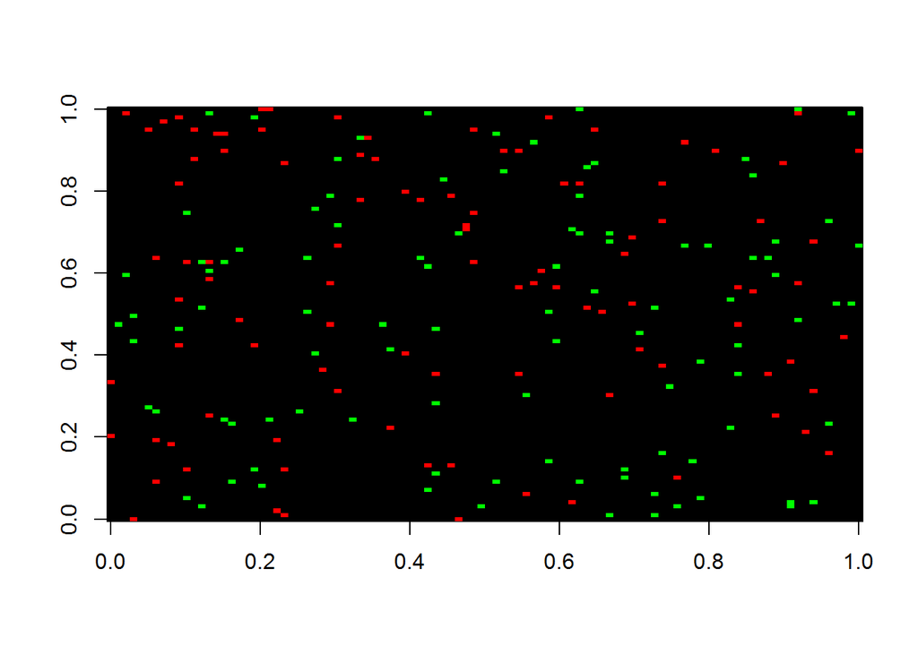

```r
# install.packages("Matrix")
library(Matrix)
grid <- .jevalArray(com$getEnvironment()$getGrid(), simplify = TRUE)[1,,]
myColors <- c("Black", "Red", "Green" )
image(grid, col = myColors)
```

#### 2.2 Removing individuals using the removeCritters class

Removing individuals is straightforward. First, I’ll add critters, and then take some away.

Add critters

```r
com <- create2SpeciesCommunity()
ac <- .jnew("AddCritters", com, as.integer(1), TRUE)
ac$addCrittersRandomly(as.integer(1000))
com$getAbundances()
```

```
## [1] 1000    0
```

OK, let’s take some away.

```r
rc <- .jnew("RemoveCritters", com, as.integer(1))
rc$removeCritters(as.integer(9))
com$getAbundances()
```

```
## [1] 991   0
```

To kill off a species entirely, find the number of individuals in that population, and then remove that many.

```r
popSize <- com$getAbundances()
rc$removeCritters(as.integer(popSize[1]))
com$getAbundances()
```

```
## [1] 0 0
```

# 3. Traversing time: step and scramble methods

#### 3.1 A few notes on dt

In the IBM, you traverse time by calling the step method. dt is the length of the step method in time units. As dt goes to zero, the IBM more closely approximates a continuous time system. If dt equals 1, one call to the step method traverses one unit of time. If dt is less than 1, traversing 1 step of time will take multiple calls to the step method. If you use the species constructor for inoculation (see 2.1.1), the program automatically calculates number of time steps until inoculation, based on dt. Example: If you tell the species to inoculate at time 10, and dt = 0.1, then the species will be inoculated after 100 calls to the step method. For more information about what’s going on behind the scenes, please reference the scaleByDt method in the community class.

If you want the system to run for a certain amount of time units, but you don’t want to calculate the number of step calls you need to make (based on dt), use `stepThroughTime`. This method automatically does the math for you: num step calls = round(time/dt). Note the rounding.

If you want to know how many step method calls have occured, use  
`com$getStepCallCounter()`

If you want to know how much time has elapsed, use `com$getTime()`

You can change dt mid-simulation, although I don’t recommend it `com$setDt(0.1)`

#### 3.2 Stepping

Execute a time step method call with…

```r
com <- create2SpeciesCommunityAndInoculate()
com$step()
```

Make multiple calls to step.

```r
com$step(as.integer(1000))
```

NOTE: why not just put `com$step()` in an R loop? Well, it just so happens that communication between R and Java is relatively expensive, not to mention that loops are slow in R. The moral is simple: if performance is critical, minimize R code and rely on the underlying Java code.

What if you want to step to a particular time (but only approximately, see 3.1, a few notes on dt)? Simple. Use stepThroughTime

```r
com$stepThroughTime(as.integer(1000))
```

## 3.3 Scrambling

In past explorations with IBMs, it has been useful to scatter/scramble up the entire community. All individuals are taken off the lattice and then re-inoculated randomly. This is one way of breaking up self-organized spatial structure.

If you want to scramble up the entire community, make a scramble object and call scramble.

```r
com <- create2SpeciesCommunityAndInoculate()
s <- .jnew("Scramble", com)
# ... and scramble away
s$scramble()
```

If you only want to scramble a subset of the species, make an array of the species Values you want to scramble, and use…

```r
s$scrambleSomeSpecies(.jarray(as.integer(1)))
```

If you want to step and then scramble right after…

```r
com$stepAndScramble()
```

If you want to do this for many step method calls…

```r
com$stepAndScramble(as.integer(100))
```

If you want to step through time (see 3.2) and then scramble after every call to the step method…

```r
# how much time do you want to elapse
com$stepAndScrambleThroughTime(as.integer(10))
```

Note that when you step through time, scramble gets called after every step method call, which is not necessarily once every time unit.

You can always devise something more intricate, like…

```r
dt <- com$setDt(0.1)
for(j in 1:100)
{
  com$step(as.integer(10))
  s <- .jnew("Scramble", com)
  s$scramble()
}
```

## 3.4 Stepping until something happens

It’s likely that you’ll want to run a simulation until something happens. Once that “thing” happens, you no longer need to keep the simulation running. Here’s the way to do that, using the stepAndMaybeTerminate method in the commuity class. This method takes the following parameters, max number of step calls, check for termination every “this many” step calls, scramble (Y/N), and your termination condition. Your termination condition is actually some object that implements the ITerminateCondition interface (an interface is a sort of contract that forces an object to have certain methods)

For example, you want to stop stepping when any species dies

```r
com <- create2SpeciesCommunityAndInoculate()
com$step()
# set dispersal higher for species 1 - farther dispersers usually displace shorter disperseres
sp1 <- com$getSpeciesList()$get(as.integer(0))
newD <- .jnew("DispersalStrategyStandard", as.integer(10), .jcast(sp1,"ISpecies"))
newD$setupAfterCommunityIsCreated(com)
sp1$setDispersalStrategy(newD)

tc<- .jnew("TerminateIfAnyoneDies", com)
com$stepAndMaybeTerminate(as.integer(1000), as.integer(1), FALSE, tc)
# see? species 1 wins
com$getAbundances()
```

```
## [1] 6633    0
```

```r
com$getStepCallCounter()
```

```
## [1] 918
```

There is a step through time variant (see 3.1 and 3.2), where you step through time and check the termination condition once every x time units.

```r
x <- 1
com$stepAndMaybeTerminateThroughTime(as.integer(1000), as.integer(x), FALSE, tc)
```

You can jerry-rig your own Termination condition in R…

```r
for(i in 1000)
{
  com$step()
  abunds <- com$getAbundances()
  if(any(abunds == 0))
  {
    break
  }
}
```

As you can see, the above is a bit simpler, but it comes at the cost of performance. Making your own ITerminateCondition object in Java should only take minute or two.

The other ITerminateCondition objects are…

`tc <- .jnew("TerminateIfSpeciesDiesOrGrowsTooLarge", com, as.integer(speciesValue), as.integer(abundUpperBound))` The above is good for invasion fitness related things. It stops if the specified species dies or grows more abundant than abundUpperBound.

And then there’s this one…

`tc <- .jnew("TerminateIfTooFewOrTooMany", com, as.integer(speciesValue), as.integer(tooFew), as.integer(tooMany))`

Here, stepping stops if a population size is too small or too large.

# 4. Time series stuff

Here, I show you how to collect data over time, including the lattice state itself.

#### 4.1 Making the time series object

All time series start with a time series object…

```r
# params
com <- create2SpeciesCommunityAndInoculate()
numSteps <- 1000
measureHowOften <- 1
throughTime <- FALSE # if true, then you step until numSteps has been reached, except in time units. Additionally, measureHowOften no longer refers to step calls, but time units. See 4.1 and 4.2 for more information
scramble <- FALSE

ts <- .jnew("TimeSeries", com, as.integer(numSteps), as.integer(measureHowOften))
# there are alternate constructors with a throughtime and scramble option. If you just use the first constructor, you never scramble or use step "through time"
ts <- .jnew("TimeSeries", com, as.integer(numSteps), as.integer(measureHowOften), throughTime)
ts <- .jnew("TimeSeries", com, as.integer(numSteps), as.integer(measureHowOften), throughTime, scramble)
```

#### 4.2 Abundance time series

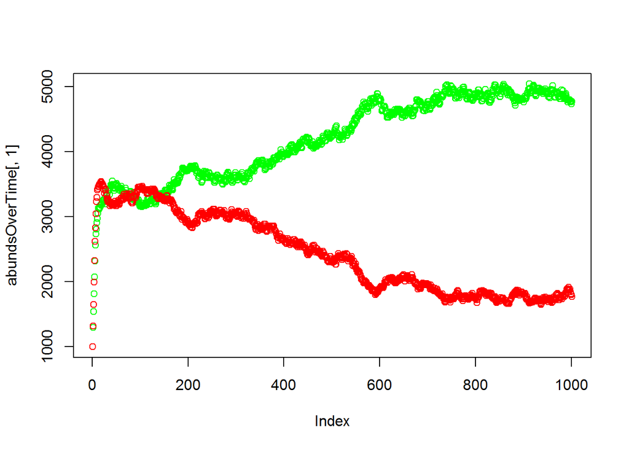

```r
com <- create2SpeciesCommunityAndInoculate()
numSteps <- 1000
measureHowOften <- 1
throughTime <- FALSE
scramble <- FALSE
ts <- .jnew("TimeSeries", com, as.integer(numSteps), as.integer(measureHowOften))


reportDensity <- FALSE # if true, gives time series in densities (num individuals/ total sites) instead of raw abundances
abundsOverTime <- .jevalArray(ts$timeSeries(reportDensity), simplify = TRUE)
maxim <- max(abundsOverTime)
plot(abundsOverTime[,1], col = "Green", ylim = c(1000, maxim))
points(abundsOverTime[,2], col = "Red")
```

#### 4.3 Grid time series

Sometimes you want to run your own functions on the entire state of the system. If there’s no individual-based evolution, then a picture of the lattice should give you the whole picture.

```r
# setup
com <- create2SpeciesCommunityAndInoculate()
numSteps <- 1000
measureHowOften <- 1
throughTime <- FALSE
scramble <- FALSE
ts <- .jnew("TimeSeries", com, as.integer(numSteps), as.integer(measureHowOften))

grids <- .jevalArray(ts$gridTimeSeries(), simplify = TRUE)
str(grids) # the first dimension is time, the second and thirdare space
```

```
##  int [1:1001, 1:100, 1:100] 0 0 0 2 2 2 0 0 0 0 ...
```

#### 4.4 Flexible time series

You can make a time series of any object that implements the ITimeSeriesQuantity interface. The interface only forces you to define two methods - get and returnLength - so making your own ITimeSeriesQuantity object is easy.

First, the same old setup.

```r
com <- create2SpeciesCommunityAndInoculate()
com$step(as.integer(10))
numSteps <- 1000
measureHowOften <- 1
throughTime <- FALSE
scramble <- FALSE
speciesValue <- 1
reportDensity <- FALSE
ts <- .jnew("TimeSeries", com, as.integer(numSteps), as.integer(measureHowOften), FALSE)
```

Here are some available objects.

```r
# lambdas correct for dt, so it's always n(t+1)/n(t)
lb <- .jnew("LambdaBar", com, as.integer(speciesValue))
lt <- .jnew("LambdaTilda", com, as.integer(speciesValue))
ldc <- .jnew("LambdaDensityCovariance", com, as.integer(speciesValue))
tsaas <- .jnew("TimeSeriesAbundAllSpecies", com, reportDensity)
tsass <- .jnew("TimeSeriesAbundSpeciesSubset", com, reportDensity, .jarray(c(as.integer(1))))

df<-as.matrix(data.frame(c(1,1,1,1), c(1,1,1,1), c(1,2,3,4)))
df <- apply(df, c(1,2), as.integer)
maxRadius <- 8
tspc <- .jnew("TimeSeriesPairCorrelation", com, as.integer(maxRadius), .jarray(df, dispatch = TRUE))

tsq <- .jnew("java.util.ArrayList")
tsq$add(lb)
```

```
## [1] TRUE
```

```r
tsq$add(lt)
```

```
## [1] TRUE
```

```r
tsq$add(ldc)
```

```
## [1] TRUE
```

```r
tsq$add(tsaas)
```

```
## [1] TRUE
```

```r
tsq$add(tsass)
```

```
## [1] TRUE
```

```r
tsq$add(tspc)
```

```
## [1] TRUE
```

```r
dat <- .jevalArray(ts$timeSeries(tsq), simplify = TRUE)
head(dat)
```

```
##         [,1]      [,2]          [,3] [,4] [,5] [,6]      [,7]      [,8]
## [1,] 1.01594 1.0131518 -0.0027882232 3011 3390 3011 0.3412488 0.3392284
## [2,] 1.01330 1.0108874 -0.0024126365 3023 3422 3023 0.3426232 0.3397287
## [3,] 1.00844 1.0079255 -0.0005144681 3055 3471 3055 0.3490180 0.3402346
## [4,] 1.00256 1.0018200 -0.0007399674 3070 3554 3070 0.3478013 0.3411238
## [5,] 0.99884 0.9986423 -0.0001977236 3075 3611 3075 0.3472358 0.3451220
## [6,] 1.00082 1.0014487  0.0006286755 3020 3633 3020 0.3408940 0.3368377
##           [,9]     [,10]
## [1,] 0.3244977 0.3160578
## [2,] 0.3286884 0.3194178
## [3,] 0.3287439 0.3227823
## [4,] 0.3328990 0.3233062
## [5,] 0.3350000 0.3303089
## [6,] 0.3260141 0.3204636
```

You can use the get method to get any of these quantities at a single point in time. For example …

```r
#gives you lambda bar
lb$get()
```

```
## [1] 1.00544
```

#### 4.5 Time series until something happens: the return of IterminateCondition

Any of the timeSeries methods we’ve seen up to this point can take one final argument: an ITerminateCondition object.

Here’s an example that re-uses most of the code in 3.4.

```r
# setup
com <- create2SpeciesCommunityAndInoculate()
com$step(as.integer(40))
sp1 <- com$getSpeciesList()$get(as.integer(0))
newD <- .jnew("DispersalStrategyStandard", as.integer(10), .jcast(sp1,"ISpecies"))
newD$setupAfterCommunityIsCreated(com)
sp1$setDispersalStrategy(newD)
numSteps <- 1000
measureHowOften <- 1
throughTime <- FALSE
scramble <- FALSE
speciesValue <- 1
reportDensity <- FALSE
ts <- .jnew("TimeSeries", com, as.integer(numSteps), as.integer(measureHowOften), FALSE)

# here are some available objects

# lambdas correct for dt, so it's always n(t+1)/n(t)
lb <- .jnew("LambdaBar", com, as.integer(speciesValue))
lt <- .jnew("LambdaTilda", com, as.integer(speciesValue))
ldc <- .jnew("LambdaDensityCovariance", com, as.integer(speciesValue))
tsaas <- .jnew("TimeSeriesAbundAllSpecies", com, reportDensity)
tsass <- .jnew("TimeSeriesAbundSpeciesSubset", com, reportDensity, .jarray(c(as.integer(1))))

df<-as.matrix(data.frame(c(1,1,1,1), c(1,1,1,1), c(1,2,3,4)))
df <- apply(df, c(1,2), as.integer)
maxRadius <- 8
tspc <- .jnew("TimeSeriesPairCorrelation", com, as.integer(maxRadius), .jarray(df, dispatch = TRUE))

tsq <- .jnew("java.util.ArrayList")
tsq$add(lb)
```

```
## [1] TRUE
```

```r
tsq$add(lt)
```

```
## [1] TRUE
```

```r
tsq$add(ldc)
```

```
## [1] TRUE
```

```r
tsq$add(tsaas)
```

```
## [1] TRUE
```

```r
tsq$add(tsass)
```

```
## [1] TRUE
```

```r
tsq$add(tspc)
```

```
## [1] TRUE
```

```r
tc<- .jnew("TerminateIfAnyoneDies", com)

dat <- .jevalArray(ts$timeSeries(tsq, tc), simplify = TRUE)
com$getAbundances()
```

```
## [1] 6675    0
```

```r
tail(dat)
```

```
##           [,1]      [,2]          [,3] [,4] [,5] [,6]      [,7]      [,8]
## [737,] 1.00034 1.0003044 -3.555898e-05 6659    2 6659 0.6668794 0.6666041
## [738,] 1.00070 1.0006814 -1.855759e-05 6653    2 6653 0.6652074 0.6653139
## [739,] 0.99698 0.9970795  9.946930e-05 6715    2 6715 0.6731013 0.6718913
## [740,] 1.00010 1.0003211  2.211084e-04 6663    2 6663 0.6665729 0.6649282
## [741,] 1.00112 1.0012425  1.225291e-04 6647    1 6647 0.6638897 0.6639587
## [742,] 0.99782 0.9976302 -1.897811e-04 6702    1 6702 0.6714787 0.6717522
##             [,9]     [,10]
## [737,] 0.6666354 0.6666391
## [738,] 0.6646813 0.6666541
## [739,] 0.6704672 0.6706031
## [740,] 0.6666854 0.6658412
## [741,] 0.6655352 0.6660599
## [742,] 0.6712082 0.6700985
```

# 5. Measuring invasion fitness

I’ll demonstrate several ways to measure invasion fitness. In each case, the general approach is the same: let the resident equilibrate, inoculate the invader, and finally measure the invader’s fitness. In the following subsections, I’ll use the same example where there is one invader species and one resident. The species are identical with one exception - the invader’s dispersal rate is greater than the resident’s dispersal rate.

This section assumes knowledge of Chessonian coexistence theory. The best resource on this topic is Chesson’s 2010 paper on spatial coexistence. It would be best to read the paper, but here’s a quick and dirty primer:

The fitness of a rare species is a measure of stable coexistence; for a species to stay in the system, it must be able to rebound if it is perturbed (for whatever reason) to a low density. We call the rare species *the invader* and the common species *the residents*. For mathematical convenience, it is usually assumed that the resident species in the system reach equilibrium before invasion fitness is measured. Here, I follow this assumption out of convention, although it is non hard to imagine some species being perturbed so quickly that the other species don’t have time to adjust their equilibria.

There are three important quantities pertaining to invasion fitness. Lambda Tilda is n(t+1)/n(t), averaged over all of the invaders. Lambda bar is n(t+1)/n(t), averaged over all sites on the lattice. Essentially, this is what invader fitness would be if the invader had no spatial structure. Lambda-fitness covariance (usually called fitness-density covariance) is the covariance between local density (on the lattice, this is binry absence/presence) and lambda ((n(t+1)/n(t))). This essentially quantifies how much self-organized spatial structure helps/hurts the species. Lambda Tilda = Lambda Bar + Lambda-Density-Covariance.

#### 5.1 Binary persistence

This is the dumb approach. Awhile after inoculation, check to see if the invader is still around. If it is, that’s a 1. If not, that’s a 0. Average this over many runs to estimate the probability of persistence (till a certain time, at least).

First, the setup

```r
gridLength = 100
dt = 1
n1InitAbund = 2000
n2InitAbund = 2000
r1 = 0.7
r2 = 0.7
d1 = 0.2
d2 = 0.2
disp1 <- 10
disp2 <- 1
list <- .jnew("java.util.ArrayList")
list$add(
  .jnew(
    "Species",
    r1,
    d1,
    as.integer(disp1)
  )
)
```

```
## [1] TRUE
```

```r
list$add(
  .jnew(
    "Species",
    r2,
    d2,
    as.integer(disp2)
  )
)
```

```
## [1] TRUE
```

```r
com <-
  .jnew(
    "Community",
    as.integer(gridLength),
    dt,
    list
  )

# now inoculate species 2, the resident...
ac <- .jnew("AddCritters", com, as.integer(2), FALSE)
ac$addCrittersRandomly(as.integer(5000))

# let it step to equilibrium. You have to make a judgment call here, though there are heuristic approaches
com$step(as.integer(3000))

# save this a reference point
gridState <- com$getEnvironment()$getGrid()

persistProb <- c()

for(i in 1:10)
{
  # revert back to the old grid state. This prevents us from having to let the residents equilibrate every invasion rep.
  # I assume that this won't lead to any appreciable psuedosampling effects, since the invader's low-density inoculation should be sufficiently random
  com$getEnvironment()$setGrid(gridState)

  # now inoculate the invader - 10 individuals
  ac <- .jnew("AddCritters", com, as.integer(1), FALSE)
  ac$addCrittersRandomly(as.integer(10))

  # now call step a maximum of 1000 times. If the invader dies or has a population of over 500, then terminate
  tc <- .jnew("TerminateIfSpeciesDiesOrGrowsTooLarge", com, as.integer(1), as.integer(500))
  com$stepAndMaybeTerminate(as.integer(1000), as.integer(50), FALSE, tc )
  invAbund <- com$getAbundances()[1]
  if(invAbund == 0)
  {
    persistProb <- append(persistProb, 0)
  } else
  {
    persistProb <- append(persistProb, 1)
  }
}

mean(persistProb)
```

```
## [1] 0.4
```

#### 5.2 Empirical lambda

```r
# first, the setup
gridLength = 100
dt = 1
n1InitAbund = 2000
n2InitAbund = 2000
r1 = 0.7
r2 = 0.7
d1 = 0.2
d2 = 0.2
disp1 <- 10
disp2 <- 1
list <- .jnew("java.util.ArrayList")
list$add(
  .jnew(
    "Species",
    r1,
    d1,
    as.integer(disp1)
  )
)
```

```
## [1] TRUE
```

```r
list$add(
  .jnew(
    "Species",
    r2,
    d2,
    as.integer(disp2)
  )
)
```

```
## [1] TRUE
```

```r
com <-
  .jnew(
    "Community",
    as.integer(gridLength),
    dt,
    list
  )

# now inoculate species 2, the resident...
ac <- .jnew("AddCritters", com, as.integer(2), FALSE)
ac$addCrittersRandomly(as.integer(5000))

# let it step to equilibrium. You have to make a judgment call here, though there are heuristic approaches
com$step(as.integer(3000))

# save this a reference point
gridState <- com$getEnvironment()$getGrid()

lambdaVec <- c()

for(i in 1:10)
{
  # revert back to the old grid state. This prevents us from having to let the residents equilibrate every invasion rep.
  # I assume that this won't lead to any appreciable psuedosampling effects, since the invader's low-density inoculation should be sufficiently random
  com$getEnvironment()$setGrid(gridState)

  # now inoculate the invader - 10 individuals
  ac <- .jnew("AddCritters", com, as.integer(1), FALSE)
  ac$addCrittersRandomly(as.integer(10))

  # try for a max of 100 step calls, measure every step
  ts <- .jnew("TimeSeries", com, as.integer(1000), as.integer(1))
  # terminate if the invader dies out or the population has grown to 100
  tc <-  .jnew("TerminateIfSpeciesDiesOrGrowsTooLarge", com, as.integer(1), as.integer(100))
  tsDat <- .jevalArray(ts$timeSeries(FALSE, tc), simplify = TRUE)[,1]
  lambda <- 0
  if(length(tsDat) > 1 )
  {
    lambda <- (tsDat[length(tsDat)] / tsDat[1]) ^ (1/(length(tsDat) -1))
  }
  lambdaVec <- append(lambdaVec, lambda)
}

mean(lambdaVec)
```

```
## [1] 0.9782928
```

#### 5.3 Expected lambda

At every time step, the average per capita fitness is measured using fitness generating functions. The outcome n(t+1)/n(t) is not measured, but the expected outcome is. This is equivalent to asking what would happen on average if the time step was replayed 1 million times. For example, a “basic species” will have expected fitness = lambda = 1 - deathProb + bmax*(proportion of sites in neighborhood that are empty). You can also measure lambda bar and fitness density covariance, which I do here for demonstrative purposes.

```r
gridLength = 100
dt = 1
n1InitAbund = 2000
n2InitAbund = 2000
r1 = 0.7
r2 = 0.7
d1 = 0.2
d2 = 0.2
disp1 <- 10
disp2 <- 1
list <- .jnew("java.util.ArrayList")
list$add(
  .jnew(
    "Species",
    r1,
    d1,
    as.integer(disp1)
  )
)
```

```
## [1] TRUE
```

```r
list$add(
  .jnew(
    "Species",
    r2,
    d2,
    as.integer(disp2)
  )
)
```

```
## [1] TRUE
```

```r
com <-
  .jnew(
    "Community",
    as.integer(gridLength),
    dt,
    list
  )

# now inoculate species 2, the resident...
ac <- .jnew("AddCritters", com, as.integer(2), FALSE)
ac$addCrittersRandomly(as.integer(5000))

# let it step to equilibrium. You have to make a judgment call here, though there are heuristic approaches
com$step(as.integer(3000))

# save this a reference point
gridState <- com$getEnvironment()$getGrid()

lambdaVec = c()
lambdaBarVec = c()
lambdaDensityCovVec = c()

for(i in 1:10)
{
  # revert back to the old grid state. This prevents us from having to let the residents equilibrate every invasion rep.
  # I assume that this won't lead to any appreciable psuedosampling effects, since the invader's low-density inoculation should be sufficiently random
  com$getEnvironment()$setGrid(gridState)

  # now inoculate the invader - 10 individuals
  ac <- .jnew("AddCritters", com, as.integer(1), FALSE)
  ac$addCrittersRandomly(as.integer(10))

  # measure invasion fitness for 1000 steps, max
  ts <- .jnew("TimeSeries", com, as.integer(1000), as.integer(1))
  tsList <- .jnew("java.util.ArrayList")

  lambdaTilda <- .jnew("LambdaTilda", com, as.integer(1))
  lambdaBar <- .jnew("LambdaBar", com, as.integer(1))
  lambdaDensityCovariance <- .jnew("LambdaDensityCovariance", com, as.integer(1))

  tsList$add(lambdaTilda)
  tsList$add(lambdaBar)
  tsList$add(lambdaDensityCovariance)

  # terminate in the case of extinction or a population size over 50
  tc <-  .jnew("TerminateIfSpeciesDiesOrGrowsTooLarge", com, as.integer(1), as.integer(50));

  tsDat <- .jevalArray(ts$timeSeries(tsList, tc), simplify = TRUE)

  # average over all measurements
  lambdaVec <- append(lambdaVec, mean(tsDat[,1]))
  lambdaBarVec <- append( lambdaBarVec, mean(tsDat[,2]))
  lambdaDensityCovVec <- append( lambdaDensityCovVec, mean(tsDat[,3]))
}

mean(lambdaVec)
```

```
## [1] 1.004806
```

```r
mean(lambdaBarVec)
```

```
## [1] 1.005096
```

```r
mean(lambdaDensityCovVec)
```

```
## [1] -0.0002896473
```

# 6 Visualizing the simulations

I don’t recommend using R to visualize simulations. You can and should use Mathematica or my OpenGL visualization in Java. If you go to mathematica, use a Do loop inside a Monitor function. You can also (and should also) plot time series along an unfolding simulation. However, if you must…

#### 6.1 R Plots and Sys.sleep

Using plot and Sys.Sleep inside a time-stepping loop draws the grid state and then pauses the whole system. The pausing is necessary so that R has time to push the lattice image to the output window before the next one is generated. The Sys.sleep time below (0.1) makes for really slow simulation visualizations, but try to go any faster and you won’t see anything.

```r
com <- create2SpeciesCommunityAndInoculate()
library(Matrix)
for(i in 1:100)
{
  com$step()
  grid <- .jevalArray(com$getEnvironment()$getGrid(), simplify = TRUE)[1,,]
  myColors <- c("Black", "Red", "Green" )
  image(grid, xaxt = "n", yaxt = "n", col = myColors)
  Sys.sleep(0.1)
}
```

#### 6.2 Animation

Use the animation package to make gifs. Don’t make them too long, or they’ll take forever to compile.

```r
library(animation)
ani.options(interval=0.0001)
saveGIF({
  for(j in 1:100)
  {
    com$step()
    grid <- .jevalArray(com$getEnvironment()$getGrid(), simplify = TRUE)[1,,]
    myColors <- c("Black", "Red", "Green" )
    image(grid, xaxt = "n", yaxt = "n", col = myColors)
  }})
```

# 7. Modifying baseline species and diffusing “general effects”

#### 7.1 What exactly is a baseline species?

A baseline species is a species whose demographic rates don’t depend on what other species are around it, the only exception being that recruitment depends on the proportion of empty neighboring sites.

#### 7.2 A motivating example: a Lotka-Volterra predator-prey community

Devising a Lotka Volterra predator-prey system presents a few instructive challenges.

First we need to change a baseline species into a prey species. A baseline species gives birth at a constant rate and so does a prey species, so nothing needs to change on the birth front. However, a prey species dies at a rate that’s proportional to the number of predators. Note that unlike a mean-field model, we only count the number of predators in some local neighborhood. We need to set the prey species death process so that the proability of death scales linearly with the number of predators. Theslope of the linear relationship is deathBaseline*alpha, where the deathBaseline is inherent to the prey’s death process and alpha is inherent to the predator’s general effect. We will do a similar thing with the predator species, except we’ll change the birth process instead of the death process.

As briefly discussed in the previous paragraph, the general effects of the predators will affect death process of the prey, whereas the general effects of the prey will affect the birth process of the predators. A few steps are necessary to turn these general effects into specific effects. First, you have to tell the predators and prey to make general effects. Then you have to tell the predator and prey species what other species can see their effects (predators need to see the preys’ general effects; prey need to see predators’ general effects). Now that the appropriate information is available to the appropriate species, we set the predator’s birth process to BirthLinear and the prey’s death process to DeathLinear.

#### 7.3 General effects

#### 7.3.1 Diffusing “general effects”

As always, the fist step is to make a generic community. The birth and death rates in the species constructor don’t matter here. We’ll overwrite them eventually.

```r
# parameters for creating species and the community.
gridLength = 100
dt = 1
n1InitAbund = 2000
n2InitAbund = 2000
r1 = 1.0
r2 = 0.2
d1 = 0.1
d2 = 0.1
disp1 <- 1
disp2 <- 2
list <- .jnew("java.util.ArrayList")
list$add(
  .jnew(
    "Species",
    r1,
    d1,
    as.integer(disp1)
  )
)
```

```
## [1] TRUE
```

```r
list$add(
  .jnew(
    "Species",
    r2,
    d2,
    as.integer(disp2)
  )
)
```

```
## [1] TRUE
```

```r
com <-
  .jnew(
    "Community",
    as.integer(gridLength),
    dt,
    list
  )
```

Now, tell the prey to diffuse out their general effects. The parameters are effect size and diffusionAbility. diffusionAbility is similar to the dispersalAbility parameter in the species constructor. It is sort of the like the radius of the square diffusion neighborhood. Technically, the length of a side of the square diffusion neighborhood is (2 * dipsersalAbility) + 1. So dispersalAbility = 1 is the 8 nearest-neighbor neighborhood, and dispersalAbility = 2 is the 24 neighbor neighborhood. The effect size is divided by the number of neighbors in the diffusion neighborhood (note that the center site is not included), and that amount of “general effect” is distributed to every neighbor. Here, both predators and prey produce an effect size of one. The effects are uniformly diffused over the `11 x 11 = 121` neighbor neighborhood.

First, we make the “general effects”…

```r
preyEffect <- .jnew("Effect", 1.0, as.integer(5))
predEffect <- .jnew("Effect", 1.0, as.integer(5))
```

There’s an Effect constructor that takes an additional argument: int indicator. `.jnew("Effect", 1, 5, indicator = 2)` The indicator can denote the type of effect, and the IBirthProcess and IDeathProcess can use this information.

For example, a species may produce mutliple types of resources that another species uses in a non-additive way. It is not enough to merely make the effect of the producing species visible to the consuming species. The consuming species also needs to know the type of resource that it’s dealing with. The indicator argument will become particularly important in quantitative cheater communities.

#### 7.3.2 Making general effects visible to other species

```r
list$get(as.integer(0))$setLocalEffect(as.integer(2), preyEffect)
list$get(as.integer(1))$setLocalEffect(as.integer(1), predEffect)
```

#### 7.4 Setting up birth and death processes

What will a species do with the “knowledge” of a “general effect”? That is to be determined in the IBirthProcess or IDeathProcess objects within the Species object. A BirthLinear concretion of IBirthProcess will tell an individual that it’s fecundity is the sum of general effects reaching that individual’ site, multiplied by some baseline birth rate. If there is no intraspecific variation in the magnitude of general effects, the sum of general effects will be effectMagnitude/ (number of neighbors in a effect diffusion neighborhood), multiplied by the number of individuals generating effects in the effect diffusion neighborhood around a site. In other words, BirthLinear leads to local lotka volterra dynamics, where the coefficient is effectSize/((2*diffusionAbility+1)^2) and the localness of the dynamics depends on the effect diffusion neighborhood.

```r
bPred <- .jnew("BirthLinear", 1)
dPred <- .jnew("DeathStandard", 0.1)

bPrey <- .jnew("BirthStandard", 0.1)
dPrey <- .jnew("DeathLinear",1)

list$get(as.integer(0))$setBirthProcess(bPrey)
list$get(as.integer(0))$setDeathProcess(dPrey)

list$get(as.integer(1))$setBirthProcess(bPred)
list$get(as.integer(1))$setDeathProcess(dPred)
```

# 8. A quantitative cheater community

A quantitative cheater community is a more complicated example of what we can do with general effects. The essential idea is that species excrete resources that other species need to survive. However, the less they produce, the more of a boost they get to their birth rate. Thus, a quantitative cheater can be thought of a somewhere between a mutualist and a cheater (hence the name, quantitative cheater). As always, see the Java code for more information.

#### 8.1 A two species community

Species 1 produces resource 1 and species 2 produce resource 2. Both species need both resources to survive. With quantitative cheaters, we have to set up the species before we construct the community. In general, this is a good rule.

First, we setup baseline species. The birth processes will get overwritten, so r1 and r2 don’t matter. Bother species have a death rate of 0.05 and a dispersalAbility/dispersalRadius of 3.

```r
gridLength = 100
dt = 1
n1InitAbund = 2000
n2InitAbund = 2000
r1 = 1.0
r2 = 1.0
d1 = 0.05
d2 = 0.05
disp1 <- 3
disp2 <- 3
list <- .jnew("java.util.ArrayList")
list$add(
  .jnew(
    "Species",
    r1,
    d1,
    as.integer(disp1)
  )
)
```

```
## [1] TRUE
```

```r
list$add(
  .jnew(
    "Species",
    r2,
    d2,
    as.integer(disp2)
  )
)
```

```
## [1] TRUE
```

To go further, we need to establish some parameters

```r
bmin1 <- 0.6
bmin2 <- 0.6
gain1 <- 0.4
gain2 <- 0.4
K <- 1.5
q1 <- 0.8
q2 <- 0.8
theta1 <- 5
theta2 <- 5
diffusion1 <- 3
diffusion2 <- 3
```

Next, we make general effects and distribute them to the appropriate species. Unlike the predator-prey example in 7., the general effects that a species produces will affect both species.

```r
# as previously discussed in 7, the last argument is the indicator. Essentially, this tells us that species 1 makes resource 1 and that species 2 makes resource 2
eff1 <- .jnew("Effect", q1, as.integer(diffusion1), as.integer(1))
eff2 <- .jnew("Effect", q2, as.integer(diffusion2), as.integer(2))

# species 1 has effects on species 1
list$get(as.integer(0))$setLocalEffect(as.integer(1), eff1)
# species 1 has effects on species 2
list$get(as.integer(0))$setLocalEffect(as.integer(2), eff1)
# species 2 has effects on species 1
list$get(as.integer(1))$setLocalEffect(as.integer(1), eff2)
# species 2 has effects on species 2
list$get(as.integer(1))$setLocalEffect(as.integer(2), eff2)
```

Next, we give species new birth processes that allow them to respond appropriately to general effects.

```r
bpQCn1 <- .jnew("BirthQuantCheat", bmin1, gain1, K, q1, theta1)
bpQCn2 <- .jnew("BirthQuantCheat", bmin2, gain2, K, q2, theta2)
list$get(as.integer(0))$setBirthProcess(bpQCn1)
list$get(as.integer(1))$setBirthProcess(bpQCn2)
```

First, we setup baseline species. The birth processes will get overwritten, so r1, r2, and r3 don’t matter. All species have a death rate of 0.05 and a dispersalAbility/dispersalRadius of 3.

```r
gridLength = 100
dt = 1
n1InitAbund = 2000
n2InitAbund = 2000
r1 = 1.0
r2 = 1.0
r3 = 1.0
d1 = 0.05
d2 = 0.05
d3 = 0.05
disp1 <- 3
disp2 <- 3
disp3 <- 3
list <- .jnew("java.util.ArrayList")
list$add(
  .jnew(
    "Species",
    r1,
    d1,
    as.integer(disp1)
  )
)
```

```
## [1] TRUE
```

```r
list$add(
  .jnew(
    "Species",
    r2,
    d2,
    as.integer(disp2)
  )
)
```

```
## [1] TRUE
```

```r
list$add(
  .jnew(
    "Species",
    r3,
    d3,
    as.integer(disp3)
  )
)
```

```
## [1] TRUE
```

```r
com <-
  .jnew(
    "Community",
    as.integer(gridLength),
    dt,
    list
  )
```

To go further, we need to establish some parameters

```r
# params for single resource producers
bmin1 <- 0.6
bmin2 <- 0.6
gain1 <- 0.4
gain2 <- 0.4
K <- 1.5
q1 <- 0.8
q2 <- 0.8
theta1 <- 5
theta2 <- 5
diffusion1 <- 3
diffusion2 <- 3

# parameters for the double producer
bmin3 <- 0.6
gain31 <- 0.01
gain32 <- 0.01
q31 <- 0.8
q32 <- 0.8
theta31 <- 5
theta32 <- 5
diffusion31 <- 3
diffusion32 <- 3
```

Next, we make general effects and distribute them to the appropriate species. Unlike the predator-prey example in 7, the general effects that a species produces will effect both species.

```r
# as previously discussed in 7, the last argument is the indicator. Essentially, this tells us that species 1 makes resource 1 and that species 2 makes resource 2
eff1 <- .jnew("Effect", q1, as.integer(diffusion1), as.integer(1))
eff2 <- .jnew("Effect", q2, as.integer(diffusion2), as.integer(2))
# species 3 producing resource 1
eff31 <- .jnew("Effect", q31, as.integer(diffusion31), as.integer(1))
# species 3 producing resource 2
eff32 <- .jnew("Effect", q32, as.integer(diffusion32), as.integer(2))


# species 1 has effects on species 1
list$get(as.integer(0))$setLocalEffect(as.integer(1), eff1)
# species 1 has effects on species 2
list$get(as.integer(0))$setLocalEffect(as.integer(2), eff1)
# species 1 has effects on species 3
list$get(as.integer(0))$setLocalEffect(as.integer(3), eff1)
# species 2 has effects on species 1
list$get(as.integer(1))$setLocalEffect(as.integer(1), eff2)
# species 2 has effects on species 2
list$get(as.integer(1))$setLocalEffect(as.integer(2), eff2)
# species 2 has effects on species 3
list$get(as.integer(1))$setLocalEffect(as.integer(3), eff2)

# species 3 has resource 1 effects on species 1
list$get(as.integer(2))$setLocalEffect(as.integer(1), eff31)
# species 3 has resource 1 effects on species 2
list$get(as.integer(2))$setLocalEffect(as.integer(2), eff31)
# species 3 has resource 1 effects on species 3
list$get(as.integer(2))$setLocalEffect(as.integer(3), eff31)
# species 3 has resource 2 effects on species 1
list$get(as.integer(2))$setLocalEffect(as.integer(1), eff32)
# species 3 has resource 2 effects on species 2
list$get(as.integer(2))$setLocalEffect(as.integer(2), eff32)
# species 3 has resource 2 effects on species 3
list$get(as.integer(2))$setLocalEffect(as.integer(3), eff32)
```

Obviously, the process of distributing effects can get tedious. You may want to loopify the above proces.

Next, we give two single-resource-producing species new birth processes that make respond to general effects appropriately

```r
bpQCn1 <- .jnew("BirthQuantCheat", bmin1, gain1, K, q1, theta1)
bpQCn2 <- .jnew("BirthQuantCheat", bmin2, gain2, K, q2, theta2)
list$get(as.integer(0))$setBirthProcess(bpQCn1)
list$get(as.integer(1))$setBirthProcess(bpQCn2)
```

Finally, we give the double producer it’s birth process. It has a slightly different, more complicated constructor that allows it to respond to any subset of resources being produced in the community

```r
bpQCn3 <- .jnew("BirthQuantCheatGen", bmin3, .jarray(c(gain31, gain32)), K, .jarray(c(q31, q32)), .jarray(c(theta31, theta32)))
list$get(as.integer(2))$setBirthProcess(bpQCn3)
```

# 9. Paired lattices: decoupling competition for space

#### 9.1 What are paired lattices and why would we want to make them?

Remember our Lotka Volterra predator-prey example from the previous section? Strangely enough, the predators competed with the prey for empty sites. While this may be appropriate in some cases where predators and prey share a common resource, it would be more accurate in most cases if prey were to only compete with prey for space and if predators were to only compete with predators for space. Still, we want the local presence of prey to affect predator dynamics and vice versa. Achieving this requires two lattices, one stacked overtop the other. The prey inhabit the bottom and can recruit on any empty sites on that lattice, regardless of whether predators occupy corresponding sites on the top lattice. However, predators and prey still diffuse general effects to one other. The effect of this setup is that competition for space is decoupled.

#### 9.2 Setting up the paired lattice

#### 9.2.1 Telling species where they live

Let’s use the predator-prey setup from section 7.

```r
gridLength = 100
dt = 1
n1InitAbund = 2000
n2InitAbund = 2000
r1 = 1.0
r2 = 0.2
d1 = 0.1
d2 = 0.1
disp1 <- 1
disp2 <- 2
list <- .jnew("java.util.ArrayList")
list$add(
  .jnew(
    "Species",
    r1,
    d1,
    as.integer(disp1)
  )
)
```

```
## [1] TRUE
```

```r
list$add(
  .jnew(
    "Species",
    r2,
    d2,
    as.integer(disp2)
  )
)
```

```
## [1] TRUE
```

```r
com <-
  .jnew(
    "Community",
    as.integer(gridLength),
    dt,
    list
  )
preyEffect <- .jnew("Effect", 1.0, as.integer(5))
predEffect <- .jnew("Effect", 1.0, as.integer(5))
list$get(as.integer(0))$setLocalEffect(as.integer(2), preyEffect)
list$get(as.integer(1))$setLocalEffect(as.integer(1), predEffect)
bPred <- .jnew("BirthLinear", 1)
dPred <- .jnew("DeathStandard", 0.1)
bPrey <- .jnew("BirthStandard", 0.1)
dPrey <- .jnew("DeathLinear",1)
list$get(as.integer(0))$setBirthProcess(bPrey)
list$get(as.integer(0))$setDeathProcess(dPrey)
list$get(as.integer(1))$setBirthProcess(bPred)
list$get(as.integer(1))$setDeathProcess(dPred)
```

Telling species where they belong is simple.

```r
# species 1 lives on lattice 1
list$get(as.integer(0))$setHomeGridValue(as.integer(1))
# species 2 lives on lattice 2
list$get(as.integer(1))$setHomeGridValue(as.integer(2))
```

#### 9.2.2 Telling species where they can or can’t recruit

By default, all species “think” that they can’t recruit occupied sites on lattice one. We need to change this.

```r
# species 1 can't recruit occupied sites on lattice 1
list$get(as.integer(0))$setEnvGridValuesThatAffectRecruitment(.jarray(c(as.integer(1))))
# species 2 can't recruit occupied sites on lattice 2
list$get(as.integer(1))$setEnvGridValuesThatAffectRecruitment(.jarray(c(as.integer(2))))
```

Notice that the method `setEnvGridValuesThatAffectRecruitment` takes an array of lattice values as an argument. If you specify more than one value in the array, then that species can’t recruit on corresponding occupied sites on any of the specified lattices.

For example…

```r
# species 1 can't recruit occupied sites on lattice 1
list$get(as.integer(0))$setEnvGridValuesThatAffectRecruitment(.jarray(c(as.integer(1,2))))
# species 1 can't recruit occupied sites on lattice 1
list$get(as.integer(1))$setEnvGridValuesThatAffectRecruitment(.jarray(c(as.integer(2))))
```

# 10. Setting the seed

Maybe you’ll need to make the simulation play out the same way every time. This is accomplished by setting the seed of various random number generators.

You have to set the seed for individual lattices. The random number generator for a lattice trickles down to all the species which inhabit that lattice, and all of the species-level and individual-level processes. Procedures that necessarily involve the whole community (e.g. scrambling, addCrittersMultipleSpecies) need random number generators too, so they get theirs from the random number generator of the lattice where the first species in the species list lives. If a species is totally unaffected by other species (i.e. it’s alone on its own lattice, its recruitment only depends on that lattice, and isn’t affected by general effects from other species), then you can set the seed on that species’ lattice and the population dynamics of that species will play out the same way on every instantiation of the IBM, regardless of whether you set the seed for other species’ lattices.

```r
com <- create2SpeciesCommunityAndInoculate()
# there's two arguments: the level of the lattice and the number you set the seed at
# here, I set the seed for the first lattice (there's only one lattice for this model) with a random integer between 1 and 10000
com$getEnvironment()$setSeedAtOneLevel(as.integer(1), as.integer(sample(1:10000, 1)));
```

# 11. Individual based evolution and intraspecific variation

#### 11.1 The setup from a software engineering point-of-view

Normally, individual based models have individual Critter objects populating some lattice. The boon of this approach is that those individual objects all have their own traits, and in turn, intraspecific variation is easily accommodated. However, this approach has a few downsides. For starters, it doesn’t scale well with lattice size in terms of memory; we could be disposing of and creating thousands of objects in each time step. primitives (i.e. integers) are more manageable. The individual object approach also beckons us to use asynchronous updating - this is where each individual tries to give birth or death in sequence. Generally, the sequence is randomized between step calls to obviate artifacts. As dt goes to zero, asynchronous updating is all fair and well. However, dt is never zero, and a miniscule dt will make the simulation run horrendously slow.

With a reasonable dt on a well populated lattice, there are bound to be some individuals who would disperse to the same empty site if only it had not been filled during the same step call. To circumvent this, I constrain birth and death rates such that the sum of the probabilities of all present propagules recruiting on an empty site is less than one, so anything can happen, including nothing at all. More importantly, the empty site perspective of the birth process allows you to use fitness generating functions to measure fitness and it’s derivatives (lambda bar, fitness density covariance), which (in my experience) is the cleanest (least noisy) way to measure fitness. We’re still left with the challenge of incorporating intraspecific variation. How can we do this if the lattice is full of integers?

Each species object tells the integers on the lattice how to behave. A basic species’ directions are encoded in some objects such as BirthProcessStandard, DeathProcessStandard, and DispersalStrategy. These objects typically implement interfaces. For the previous examples, these are IBirthProcess, IDeathProcess, and IDispersalStrategy, respectively. Each species also has a Traitlist Object, which holds traits that implement an Evolvable interface. These traits are either subclasses of ContinuousTrait or DiscreteTrait(which itself is a subclass of ContinuousTrait). These evolvable traits implement an interface that the Species requires. For example, every species requires an IDispersalStrategy object, so let’s consider the DispersalIB object (IB stands for individual-based). DispersalIB implements both the IDispersalStrategy and the Evolvable interface. Let’s assume that you put the DispersalIB in a species’s TraitList. The DispersalIB object gains access its species owner as an instance variable. When you tell the DispersalIB object to start evolving, it overwrites the IDispersalStrategy object that the species was previously using. Each trait has it’s own lattice for tracking the spatial distribution of it’s values. Deletions of trait values (with death) or additions (from births) are all managed by the TraitList object.

Offspring inherit traits from their progenitors. When evolution is turned on, offspring traits can deviate from from their parent’s traits via mutation functions (see 11.2). This means that **the evolution process is coupled with the birth process**. It’s also worth reiterating that there is no sexual reproduction.

For propagules to know what traits they will have if they recruit, each propagule package from each progenitor is associated with the progenitor’s location with a HashMap. When dispersal neighborhoods are large and many propagules are dispersing from many progenitors, simulations can slow down significantly. The program has some logic that attempts to keep the simulation running as fast as possible. If you’re interested in the details, the logic is in the PGR class (propagule rain grid). Here I present a high-level view of what to expect. When dispersal is the only individual based trait, a distinct algorithm is used. It’s pretty fast, and shouldn’t cause major slow downs even at high dispersal abilities. When dispersal is high (> 20) and there are individual based traits, but all of those traits are constrained to discrete values, expect a moderate slow-down. If dispersal is high, and there are other individual based traits, and one or more are continuous in nature, then the simulation is really going to drag.

#### 11.2 The key ingredient: a mutation function

Each and every Evovable Trait constructor takes a mutation function as it’s first argument. Each mutation function is forced to implement the IMutationFunction interface. Each mutation function takes two doubles as arguments. The first is the probability of mutation, the second is the standard deviation of a guassian distribution from which additions to old trait values are drawn.

Here are some mutation functions…

```r
# params
mutationMagnitude <- 0.5
evolveProb <- 0.05

#This rounds mutations to non-negative integers. Good for evolving the diffusiveness of interactions. Not great for dispersal, since dispersal can't be zero
mfDifn1 <- .jnew("MutationFunctionDiscreteBoundedByZero",evolveProb, mutationMagnitude)

#This is for continuous traits that can assume any real number. Good for evolving effect values of "excreted" resources
mfEffn1 <- .jnew("MutationFunctionContinuous",evolveProb, mutationMagnitude)

#This round mutations to non-negative, non-zero integers. Good for evolving dispersal
mfDispn1 <- .jnew("MutationFunctionDiscreteBoundedByOne",evolveProb, mutationMagnitude)

#This is for continuous traits that cannot be less than zero. Good for evolving birth rate, evolution probabilities, ect.
mfDispn1 <- .jnew("MutationFunctionDiscreteBoundedByOne",evolveProb, mutationMagnitude)
```

TAKE NOTE: when mutation functions are given to evolvable traits, they must be cast as IMutationFunction

All mutation functions operate by the mutate method. To see the mutation function in action, we must first give a random number generator to the mutation function. Normally, this is done behind the scenes when a evolvable trait is added to a species (more on that later).

```r
mutationMagnitude <- 0.5
evolveProb <- 0.05
oldTrait <-5
mfEffn1 <- .jnew("MutationFunctionContinuous",evolveProb, mutationMagnitude)
mfEffn1$setGenerator(.jnew("java.util.Random"))
imax <- 1000
mutVec <- rep(NA, imax)
for(i in 1:imax)
{
 mutVec[i] <- mfEffn1$mutate(oldTrait)
}
#this the empirical probability of mutation
length(which(mutVec!=oldTrait))/length(mutVec)
```

```
## [1] 0.042
```

#### 11.3 How to start evolution: an example with dispersal distance

We setup a basic community; make mutation function; use the mutation function to make a DisersalIB objection; and we give the DispersalIB object (which implements IDispersalStrategy) to the first species.

```r
# setup a basic community
com <- create2SpeciesCommunityAndInoculate()
#first make the mutation function
mutationMagnitude <- 2
evolveProb <- 0.05
mfDispn1 <- .jcast(.jnew("MutationFunctionDiscreteBoundedByOne",evolveProb, mutationMagnitude), "IMutationFunction")
#then use it to construct a dispersalIB object (IB for individual based)
dispIB <- .jnew("DispersalIB", mfDispn1)
# give the evolvable trait to the first species
com$getSpeciesList()$get(as.integer(0))$addTrait(dispIB)
```

Now we let the system run for a bit and collect data, the species should behave neutrally.

```r
#let the system run for a bit...
ts <- .jnew("TimeSeries", com, as.integer(1000), as.integer(1))
abundsOverTime <- .jevalArray(ts$timeSeries(TRUE), simplify = TRUE)
```

Time to start evolution

```r
dispIB$startEvolution()
```

If you ever lose track of your evolvable trait, you can find it deep within the species. If you forget what type of trait it is, you can guess with .jinstanceof

```r
trait <- com$getSpeciesList()$get(as.integer(0))$getEvolvableTraits()$get(as.integer(0))
.jinstanceof(trait, "IDispersalTrait")
```

```
## [1] TRUE
```

You can learn a lot about a trait with the following methods.

```r
trait$isContinuous()
```

```
## [1] FALSE
```

```r
trait$isDiscrete()
```

```
## [1] TRUE
```

```r
trait$isIndividualBased()
```

```
## [1] TRUE
```

```r
trait$isEvolving()
```

```
## [1] TRUE
```

Run for the system for a bit and collect more data

```r
#let the system run for a bit...
ts1 <- .jnew("TimeSeries", com, as.integer(2000), as.integer(1))
abundsOverTime <- rbind(abundsOverTime, .jevalArray(ts1$timeSeries(TRUE), simplify = TRUE))
```

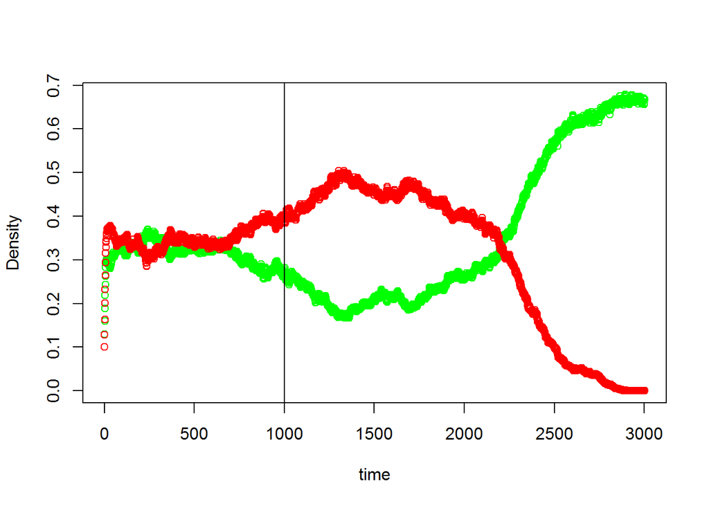

```r
maxim <- max(abundsOverTime)
plot(abundsOverTime[,1], col = "Green", ylim = c(0, maxim), xlab = "time", ylab = "Density")
points(abundsOverTime[,2], col = "Red")
abline(v=1000)
```

The green species evolves larger dispersal neighborhoods and beats out the red species. Higher dispersal is advantageous because there’s a reduced chance of landing on your brothers/cousins etc.

#### 11.4 Stopping evolution

If you want to stop the evolution of a trait, simply use

```r
trait$stopEvolution()
```

There will still be intraspecific variation, but mutations will no longer occur. Turning off evolution may help you determine if there is a stable polymorphism, since continual evolution can supply a slightly un-optimal trait mode (like a genetic mass effect). Another way to detect stable polymorphisms is to turn down the probability of mutation.

#### 11.5 Getting individual-based trait data

#### 11.5.1 Getting trait data for any type of trait

```r
dat <- .jevalArray(dispIB$getSpatialDistributionTrackerData(), simplify = TRUE)
```

This method returns a lattice full of NaNs and double-precision numbers. The numbers are the trait values of the trait’s species. The NaNs are sites that the trait’s species does not occupy. It it unreliable to represent unoccupied sites with zeros (like the Environment’s lattice), since traits can also take on a value of zero.

Make sure not to accidentally use `getSpatialDistributionTracker`. This method is essential for the inner workings of the model, but it will return a lattice where zeros denote unoccupied sites *or* zero-valued traits.

If you just want the average values of a trait, use…

```r
dispIB$getTraitAverage()
```

```
## [1] 12.71294
```

#### 11.5.2 Getting trait data for discrete traits

Certain traits can only take on discrete values. Dispersal Ability and Diffusion ability (of general effects) are two such traits.

If you want the number of individuals that take on each discrete value (i.e. histogram data) use…

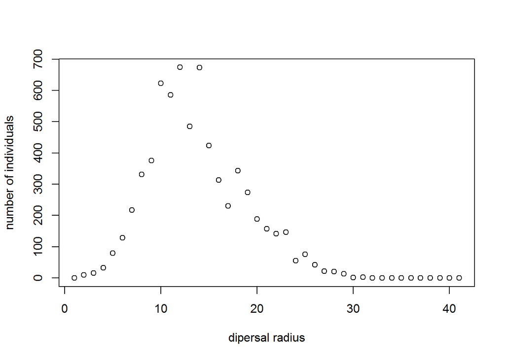

```r
histDat <- dispIB$getDiscreteHistogram()
plot(histDat, xlab = "dipersal radius", ylab = "number of individuals")
```

Notice that there are a lot of zeros here. Don’t worry about this; it’s an artifact of the model’s inner workings.

If you want the maximum trait value, use…

```r
dispIB$getMaxTraitValue()
```

```
## [1] 30
```

If you want the minimum trait value, use…

```r
dispIB$getMinTraitValue()
```

```
## [1] 1
```

First, we set up the predator-prey community.

```r
gridLength = 100
dt = 1
r1 = 1.0
r2 = 0.2
d1 = 0.1
d2 = 0.1
disp1 <- 1
disp2 <- 1
list <- .jnew("java.util.ArrayList")
list$add(
  .jnew(
    "Species",
    r1,
    d1,
    as.integer(disp1)
  )
)
```

```
## [1] TRUE
```

```r
list$add(
  .jnew(
    "Species",
    r2,
    d2,
    as.integer(disp2)
  )
)
```

```
## [1] TRUE
```

```r
com <-
  .jnew(
    "Community",
    as.integer(gridLength),
    dt,
    list
  )
preyEffect <- .jnew("Effect", 1.0, as.integer(2))
predEffect <- .jnew("Effect", 1.0, as.integer(2))
list$get(as.integer(0))$setLocalEffect(as.integer(2), preyEffect)
list$get(as.integer(1))$setLocalEffect(as.integer(1), predEffect)
bPred <- .jnew("BirthLinear", 1)
dPred <- .jnew("DeathStandard", 0.1)
bPrey <- .jnew("BirthStandard", 0.1)
dPrey <- .jnew("DeathLinear",1)
list$get(as.integer(0))$setBirthProcess(bPrey)
list$get(as.integer(0))$setDeathProcess(dPrey)
list$get(as.integer(1))$setBirthProcess(bPred)
list$get(as.integer(1))$setDeathProcess(dPred)
```

We need mutation functions for the diffusiveness of interactions. Here, we use MutationFunctionDiscreteBoundedByZero. This is much like the mutation function that is used for the evolution of dispersal, except the trait can now assume a value of zero.

```r
mfDifn1 <- .jcast(.jnew("MutationFunctionDiscreteBoundedByZero", 0.05, 2), "IMutationFunction")
```

```r
.jconstructors("DiffusionIB")
```

```
## [1] "public DiffusionIB(IMutationFunction,int,int,IEffect)"
```

```r
diffusionEvolven1 <- .jnew("DiffusionIB", mfDifn1, as.integer(2), as.integer(1), .jcast(preyEffect, "IEffect"))
com$getSpeciesList()$get(as.integer(0))$addTrait(diffusionEvolven1)
```

Inoculate both species and step for a while to reach a quasi-equilibrium.

```r
ac <- .jnew("AddCritters", com, as.integer(1), FALSE)
ac$addCrittersRandomly(as.integer(2000))
ac <- .jnew("AddCritters", com, as.integer(2), FALSE)
ac$addCrittersRandomly(as.integer(2000))
com$step(as.integer(1000))
```

This is what the quasi-equilibrium looks like. Green is the prey, red is the predator.

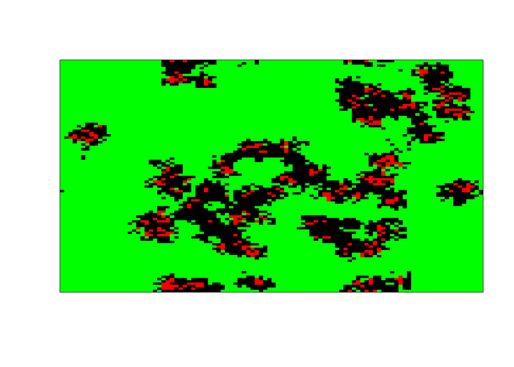

```r
grid <- .jevalArray(com$getEnvironment()$getGrid(), simplify = TRUE)[1,,]
myColors <- c("Black", "Green", "Red" )
image(grid, xaxt = "n", yaxt = "n", col = myColors)
```

What happens if the diffusiveness of the prey’s effect on the predator is allowed to evolve?

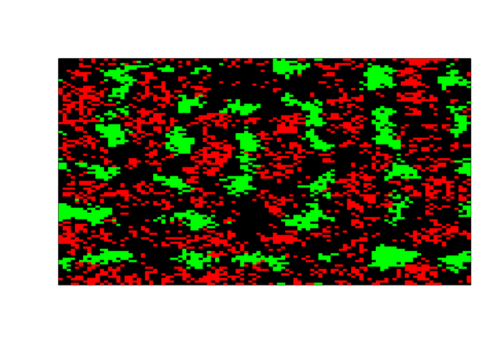

```r
diffusionEvolven1$startEvolution()
com$step(as.integer(2000))
grid <- .jevalArray(com$getEnvironment()$getGrid(), simplify = TRUE)[1,,]
myColors <- c("Black", "Green", "Red" )
image(grid, xaxt = "n", yaxt = "n", col = myColors)
```

Looks like we evolved our way into a Turing-like pattern!

What about the magnitude of the general effects? Let’s evolve that for both the predator and the prey. We will be allowing the predators to evolve their effect on the prey. That might seem backwards. Shouldn’t the prey be evolving defense? Maybe they should. Doing so would require coding an evolvable trait that also implements the IBirthProcess object of the prey. Consider it a challenge! For now, we stick to the original example.

First, we set up the predator-prey community.

```r
gridLength = 100
dt = 1
r1 = 1.0
r2 = 0.2
d1 = 0.1
d2 = 0.1
disp1 <- 1
disp2 <- 1
list <- .jnew("java.util.ArrayList")
list$add(
  .jnew(
    "Species",
    r1,
    d1,
    as.integer(disp1)
  )
)
```

```
## [1] TRUE
```

```r
list$add(
  .jnew(
    "Species",
    r2,
    d2,
    as.integer(disp2)
  )
)
```

```
## [1] TRUE
```

```r
com <-
  .jnew(
    "Community",
    as.integer(gridLength),
    dt,
    list
  )
preyEffect <- .jnew("Effect", 1.0, as.integer(2))
predEffect <- .jnew("Effect", 1.0, as.integer(2))
list$get(as.integer(0))$setLocalEffect(as.integer(2), preyEffect)
list$get(as.integer(1))$setLocalEffect(as.integer(1), predEffect)
bPred <- .jnew("BirthLinear", 1)
dPred <- .jnew("DeathStandard", 0.1)
bPrey <- .jnew("BirthStandard", 0.1)
dPrey <- .jnew("DeathLinear", 1)
list$get(as.integer(0))$setBirthProcess(bPrey)
list$get(as.integer(0))$setDeathProcess(dPrey)
list$get(as.integer(1))$setBirthProcess(bPred)
list$get(as.integer(1))$setDeathProcess(dPred)
```

We need mutation functions for the effect. Here, we use MutationFunctionContinuous. There are no limitations on what trait values this mutation function will output. Any real number will suffice

```r
mfEffn1 <- .jcast(.jnew("MutationFunctionContinuous", 0.05, 0.05), "IMutationFunction")
mfEffn2 <- .jcast(.jnew("MutationFunctionContinuous", 0.05, 0.20), "IMutationFunction")
```

Now, we create traits (one for the predator, one for the prey) that allow the magnitude of the general effects to evolve. The class is EffectValueIB and the parameters are IMutationFunction mf, int affectedSpeciesValue, int affectedSpeciesLVEffectValue, IEffect lvEffectToOverwrite. For the prey’s evolving trait, affectedSpeciesValue is 2 (the prey affects the predator, which is species 2). The third parameter, affectedSpeciesLVEffectValue, is basically the “normal index” (see 1.2.4) of the traits that go from prey to predator. This is undoubtedly a complication, but it is necessary so that the evolvable trait knows where the general effect trait exists (so it can be replaced). The indexing of traits goes by the order in which traits where given from species A to species B via `setLocalEffect`. Here, the prey only has one effect on the predator, the argument is 1.

```r
.jconstructors("EffectValueIB")
```

```
## [1] "public EffectValueIB(IMutationFunction,int,int,IEffect)"
```

```r
effEvolven1 <- .jnew("EffectValueIB", mfEffn1, as.integer(2), as.integer(1), .jcast(preyEffect, "IEffect"))
effEvolven2 <- .jnew("EffectValueIB", mfEffn2, as.integer(1), as.integer(1), .jcast(predEffect, "IEffect"))
com$getSpeciesList()$get(as.integer(0))$addTrait(effEvolven1)
com$getSpeciesList()$get(as.integer(1))$addTrait(effEvolven2)
```

Inoculate both species and start evolution

```r
ac <- .jnew("AddCritters", com, as.integer(1), FALSE)
ac$addCrittersRandomly(as.integer(2000))
ac <- .jnew("AddCritters", com, as.integer(2), FALSE)
ac$addCrittersRandomly(as.integer(2000))

effEvolven1$startEvolution()
effEvolven2$startEvolution()
```

#### 11.8 evolving mutation proabilities

Can evolution evolve? In the IBM, mutation functions can involve in two ways. One way is allowing the probabililty of mutation to evolve. We need one other evolving trait so that having a mutation function is even relevant. Let’s return to the dispersal evolution example.

```r
# setup a basic community
com <- create2SpeciesCommunityAndInoculate()
#first make the mutation function
mutationMagnitude <- 2
evolveProb <- 0.05
mfDispn1 <- .jcast(.jnew("MutationFunctionDiscreteBoundedByOne",evolveProb, mutationMagnitude), "IMutationFunction")
#then use it to construct a dispersalIB object (IB for individual based)
dispIB <- .jnew("DispersalIB", mfDispn1)
# give the evolvable trait to the first species
com$getSpeciesList()$get(as.integer(0))$addTrait(dispIB)
# start evolution
dispIB$startEvolution()
```

We have to make a separate mutation function for the probability of dispersal mutations.

```r
mfEvolveProb <- .jcast(.jnew("MutationFunctionContinuousBoundedByZero", 0.05, 0.05), "IMutationFunction")
```

Now, create an evolveProbIB object. Notice that it takes an IMutationFunction as it’s last argument.

```r
evolveProbEvolve <- .jnew("EvolveProbIB", mfEvolveProb, mfDispn1)
```

give the new evolvable trait to the species and start the evolution of mutation probability.

```r
com$getSpeciesList()$get(as.integer(0))$addTrait(evolveProbEvolve)
evolveProbEvolve$startEvolution()
```

```r
com$step(as.integer(500))
res <- evolveProbEvolve$getTraitAverage()
```

the probability of dispersal mutation has evolved from 0.05 to 0.0663821.

You can even evolve the evolution of evolution, and so forth.

```r
mfEvolveEvolveProb <- .jcast(.jnew("MutationFunctionContinuousBoundedByZero", 0.05, 0.05), "IMutationFunction")
evolveProbEvolveEvolve <- .jnew("EvolveProbIB", mfEvolveEvolveProb, mfEvolveProb)
# ad infinitum...
```

Here, we are combining dispersal evolution with continuous traits. As mentioned in 11.1, simulation slow-downs will occur if dispersal evolves to high values.

#### 11.9 Evolving mutation magnitudes

When a trait mutates, the parental trait is added to a random variable. All random variables in my mutation functions are drawn from a guassian distribution. I call the standard deviation of this distribution “mutation magnitude”. Let’s evolve mutations magnitudes.

Note: In reality, mutation magnitude does not need to be a standard deviation, it could a constant that is added or subtracted whenever a mutation occurs. The distribution of trait additions need not be guassian either. Write your own IMutationFunction!

```r
# setup a basic community
com <- create2SpeciesCommunityAndInoculate()
#first make the mutation function
mutationMagnitude <- 2
evolveProb <- 0.05
mfDispn1 <- .jcast(.jnew("MutationFunctionDiscreteBoundedByOne",evolveProb, mutationMagnitude), "IMutationFunction")
#then use it to construct a dispersalIB object (IB for individual based)
dispIB <- .jnew("DispersalIB", mfDispn1)
# give the evolvable trait to the first species
com$getSpeciesList()$get(as.integer(0))$addTrait(dispIB)
# start evolution
dispIB$startEvolution()
```

```r
mfMM<- .jcast(.jnew("MutationFunctionContinuousBoundedByZero", 0.05, 0.5), "IMutationFunction")
```

```r
MMEvolve <- .jnew("MutationMagnitudeIB", mfMM, mfDispn1)
```

```r
com$getSpeciesList()$get(as.integer(0))$addTrait(MMEvolve)
MMEvolve$startEvolution()
```

```r
com$step(as.integer(500))
res <- MMEvolve$getTraitAverage()
```

The mutation magnitude has evolved from 2 to 1.7766455.

You can even evolve the evolution of mutation magnitude, and so forth.

```r
mfEvolveMM <- .jcast(.jnew("MutationFunctionContinuousBoundedByZero", 0.05, 0.05), "IMutationFunction")
evolveProbEvolveEvolve <- .jnew("EvolveProbIB", mfEvolveMM, mfMM)
# ad infinitum...
```

Here, we are combining dispersal evolution with continuous traits. As mentioned in 11.1, simulation slow-downs will occur if dispersal evolves to high values.

#### 11.10 Evolving q: An example with quantitative cheaters

Let’s return to the quantitative cheater example (see 8.) and evolve q, the density of resource that a quantitative cheater excretes. As with the regular quantitative cheater community, species must be created in full (traits included) before the community is constructed.

First, we recreate the two quantitative cheaters.

```r
gridLength = 100
dt = 1
n1InitAbund = 2000
n2InitAbund = 2000
r1 = 1.0
r2 = 1.0
d1 = 0.05
d2 = 0.05
disp1 <- 3
disp2 <- 3
list <- .jnew("java.util.ArrayList")
list$add(
  .jnew(
    "Species",
    r1,
    d1,
    as.integer(disp1)
  )
)
```

```
## [1] TRUE
```

```r
list$add(
  .jnew(
    "Species",
    r2,
    d2,
    as.integer(disp2)
  )
)
```

```
## [1] TRUE
```

```r
bmin1 <- 0.6
bmin2 <- 0.6
gain1 <- 0.4
gain2 <- 0.4
K <- 1.5
q1 <- 0.8
q2 <- 0.8
theta1 <- 5
theta2 <- 5
diffusion1 <- 3
diffusion2 <- 3
# as discussed in 7, the last argument is the indicator. Essentially, this tells us that species 1 makes resource 1 and that species 2 makes resource 2
eff1 <- .jnew("Effect", q1, as.integer(diffusion1), as.integer(1))
eff2 <- .jnew("Effect", q2, as.integer(diffusion2), as.integer(2))
# species 1 has effects on species 1
list$get(as.integer(0))$setLocalEffect(as.integer(1), eff1)
# species 1 has effects on species 2
list$get(as.integer(0))$setLocalEffect(as.integer(2), eff1)
# species 2 has effects on species 1
list$get(as.integer(1))$setLocalEffect(as.integer(1), eff2)
# species 2 has effects on species 2
list$get(as.integer(1))$setLocalEffect(as.integer(2), eff2)
bpQCn1 <- .jnew("BirthQuantCheat", bmin1, gain1, K, q1, theta1)
bpQCn2 <- .jnew("BirthQuantCheat", bmin2, gain2, K, q2, theta2)
list$get(as.integer(0))$setBirthProcess(bpQCn1)
list$get(as.integer(1))$setBirthProcess(bpQCn2)
```

Q is complicated trait (QuantCheatQIB). It is simultaneously the magnitude of a general effect (class IEffect) and an important variable in the quantitative cheater birth process (IBirthProcess). When q starts evolving, it overwrites the q object in the Effect object *and* the QuantCheatBirth object.

The parameters for the QuantCheatQIB constructor are IMutationFunction mf, int indicator. The indicator is the type of resource that q refers to. We’ll evolve q of species 1, which creates resource 1.

```r
mfQn1 <- .jcast(.jnew("MutationFunctionContinuousBoundedBetweenZeroAndOne", 0.2, 0.05), "IMutationFunction")
evolveQn1 <- .jnew("QuantCheatQIB", mfQn1, as.integer(1))
com$getSpeciesList()$get(as.integer(0))$addTrait(evolveQn1)
```